# morphology_analysis

Allison Davis

November 21, 2019

## *Morphological variation of amazon and sailfin mollies*

In this study, I am looking at various populations of amazon and sailfin mollies across their native/introduced range to assess morphological variation both within and among the species. I am using the Pickle fish collections for my samples.

### Data collection

```
## Using libcurl 7.64.1 with Schannel
```

```
##   X.U.FEFF.TNHC.. COUNTY.ST                            LOCATION SAMPLING.DATE
## 1           47942 Nueces/TX ditch crossing SH 361 @ Howard Blvd      24-09-11
## 2           47942 Nueces/TX ditch crossing SH 361 @ Howard Blvd      24-09-11
## 3           47942 Nueces/TX ditch crossing SH 361 @ Howard Blvd      24-09-11
## 4           47942 Nueces/TX ditch crossing SH 361 @ Howard Blvd      24-09-11
## 5           47942 Nueces/TX ditch crossing SH 361 @ Howard Blvd      24-09-11
## 6           47942 Nueces/TX ditch crossing SH 361 @ Howard Blvd      24-09-11
##   MEASUREMENT.DATE PHOTO.DATE    TAG..  D P1 P2.L P2.R  A P1.R LLSC SALL SBLL
## 1         20-03-19         NA AD19-001 14 14    6    6  9   14   26    3    5
## 2         15-03-19         NA AD19-002 14 14    6    6  9   14   25    2    5
## 3         15-03-19         NA AD19-003 13 13    6    6  9   13   26    3    5
## 4         15-03-19         NA AD19-004 14 13    6    6  9   13   26    4    5
## 5         18-03-19         NA AD19-005 14 13    6    6  9   13   26    3    5
## 6         18-03-19         NA AD19-006 14 13    6    6 NA   13   26    3    5
##   SBDF   TL   SL   BD CPD  CPL PreDL  DbL   HL   HD   HW SnL  OL         SPP
## 1    9 54.8 41.7 15.6 7.8 12.6  22.3 11.3 10.0 10.5  9.2 3.7 3.5 p.latipinna
## 2    9 53.0 42.9 14.9 8.5 13.0  20.9 11.2 13.3  9.5  8.3 3.7 3.4 p.latipinna
## 3    8 68.2 52.9 16.0 9.6 16.7  25.9 13.0 14.0 11.0 10.2 4.4 3.7 p.latipinna
## 4    9 41.1 32.7 11.3 5.9 10.2  16.9  8.2 10.0  7.3  6.7 2.6 2.6 p.latipinna
## 5    8 53.1 42.2 13.4 7.0 12.8  21.1 10.7  9.2  9.5  8.1 2.8 3.3 p.latipinna
## 6    9 50.9 40.0 13.7 8.0 11.9  20.5 11.0  9.2 10.7  8.4 2.8 3.1 p.latipinna
```

```
##   X.U.FEFF.TNHC.. COUNTY.ST                            LOCATION SAMPLING.DATE
## 1           47942 Nueces/TX ditch crossing SH 361 @ Howard Blvd      24-09-11
## 2           47942 Nueces/TX ditch crossing SH 361 @ Howard Blvd      24-09-11
## 3           47942 Nueces/TX ditch crossing SH 361 @ Howard Blvd      24-09-11
## 4           47942 Nueces/TX ditch crossing SH 361 @ Howard Blvd      24-09-11
## 5           47942 Nueces/TX ditch crossing SH 361 @ Howard Blvd      24-09-11
## 6           47942 Nueces/TX ditch crossing SH 361 @ Howard Blvd      24-09-11
##   MEASUREMENT.DATE PHOTO.DATE    TAG..  D P1 P2.L P2.R  A P1.R LLSC SALL SBLL
## 1         20-03-19         NA AD19-001 14 14    6    6  9   14   26    3    5
## 2         15-03-19         NA AD19-002 14 14    6    6  9   14   25    2    5
## 3         15-03-19         NA AD19-003 13 13    6    6  9   13   26    3    5
## 4         15-03-19         NA AD19-004 14 13    6    6  9   13   26    4    5
## 5         18-03-19         NA AD19-005 14 13    6    6  9   13   26    3    5
## 6         18-03-19         NA AD19-006 14 13    6    6 NA   13   26    3    5
##   SBDF   TL   SL   BD CPD  CPL PreDL  DbL   HL   HD   HW SnL  OL         SPP
## 1    9 54.8 41.7 15.6 7.8 12.6  22.3 11.3 10.0 10.5  9.2 3.7 3.5 p.latipinna
## 2    9 53.0 42.9 14.9 8.5 13.0  20.9 11.2 13.3  9.5  8.3 3.7 3.4 p.latipinna
## 3    8 68.2 52.9 16.0 9.6 16.7  25.9 13.0 14.0 11.0 10.2 4.4 3.7 p.latipinna
## 4    9 41.1 32.7 11.3 5.9 10.2  16.9  8.2 10.0  7.3  6.7 2.6 2.6 p.latipinna
## 5    8 53.1 42.2 13.4 7.0 12.8  21.1 10.7  9.2  9.5  8.1 2.8 3.3 p.latipinna
## 6    9 50.9 40.0 13.7 8.0 11.9  20.5 11.0  9.2 10.7  8.4 2.8 3.1 p.latipinna
```

```
##    X.U.FEFF.TNHC.. COUNTY.ST                                      LOCATION
## 29           42620 Nueces/TX Petronila Creek, 60-100m downstream from US77
## 30           42620 Nueces/TX Petronila Creek, 60-100m downstream from US78
## 31           42620 Nueces/TX Petronila Creek, 60-100m downstream from US79
## 32           42620 Nueces/TX Petronila Creek, 60-100m downstream from US80
## 33           42620 Nueces/TX Petronila Creek, 60-100m downstream from US81
## 34           42620 Nueces/TX Petronila Creek, 60-100m downstream from US82
##    SAMPLING.DATE MEASUREMENT.DATE PHOTO.DATE    TAG..  D P1 P2.L P2.R  A P1.R
## 29     19-3-2009         21-03-19         NA AD19-026 13 14    6    6  9   14
## 30     19-3-2009         21-03-19         NA AD19-027 12 14    6    6  9   14
## 31     19-3-2009         21-03-19         NA AD19-028 11 14    6    6  9   14
## 32     19-3-2009         21-03-19         NA AD19-029 12 14    6    6 10   14
## 33     19-3-2009         21-03-19         NA AD19-030 13 14    6    6  9   15
## 34     19-3-2009         21-03-19         NA AD19-031 11 14    6    6 10   15
##    LLSC SALL SBLL SBDF   TL   SL   BD CPD  CPL PreDL DbL  HL  HD  HW SnL  OL
## 29   25    4    5   10 60.0 47.3 15.1 8.7 15.6  25.1 9.8 9.1 8.0 9.1 4.0 3.8
## 30   24    4    5    9 48.5 37.2 12.2 7.0 11.2  20.5 8.4 7.2 7.7 7.4 3.0 3.5
## 31   24    4    5    9 43.7 32.7 10.1 5.9  9.6  19.5 6.8 7.2 6.4 6.5 2.8 3.1
## 32   24    4    5    9 50.3 37.6 13.1 7.4 11.5  22.1 8.3 8.3 7.9 7.8 3.4 3.3
## 33   25    3    5   10 52.8 41.1 14.2 7.7 12.9  23.2 8.6 9.0 7.8 8.2 3.8 3.8
## 34   24    4    5   10 47.9 36.8 11.3 6.7 11.1  21.6 7.2 7.4 7.3 7.0 3.3 3.4
##          SPP
## 29 p.formosa
## 30 p.formosa
## 31 p.formosa
## 32 p.formosa
## 33 p.formosa
## 34 p.formosa
```

### PCA analysis

In this analysis, I will compare the principle components after centering and scaling the data. A PCA analysis will help us determine what aspects of morphology influence the variation in our data the most without worrying about differences in scales/measurements. Currently, data consists of **28 Sailfin and 45 Amazon**.

*Will use the original raw data set rather than any outlier-removed data sets.*

*Variable chart:*

- D: dorsal ray count
- P1: left pectoral ray count
- P2.L: left pelvic rays
- P2.R: right pelvic rays
- A: anal rays
- P1.R: right pectoral ray count
- LLSC: lateral line scale count
- SALL: scales above lateral line
- SBLL: scales below lateral line
- SBDF: scales before dorsal fin
- TL: total length
- SL: standard length
- BD: body depth
- CPD: caudal peduncle depth
- CPL: caudal peduncle length
- PreDL: pre-dorsal length
- DbL: dorsal base length
- HL/HW/HD: head length/width/depth
- SnL: snout length
- OL: ocular length
- summary of PCs

```
## Importance of components:
##                           PC1    PC2     PC3     PC4     PC5     PC6     PC7
## Standard deviation     3.2825 1.7110 1.38089 1.13809 0.99270 0.93718 0.86934
## Proportion of Variance 0.4898 0.1331 0.08668 0.05887 0.04479 0.03992 0.03435
## Cumulative Proportion  0.4898 0.6228 0.70952 0.76839 0.81319 0.85311 0.88746
##                           PC8     PC9    PC10    PC11    PC12    PC13    PC14
## Standard deviation     0.7960 0.70129 0.65094 0.51284 0.42312 0.36752 0.34536
## Proportion of Variance 0.0288 0.02236 0.01926 0.01195 0.00814 0.00614 0.00542
## Cumulative Proportion  0.9163 0.93862 0.95788 0.96984 0.97797 0.98411 0.98953
##                           PC15    PC16    PC17   PC18   PC19    PC20    PC21
## Standard deviation     0.30506 0.22922 0.17517 0.1557 0.1406 0.08240 0.05635
## Proportion of Variance 0.00423 0.00239 0.00139 0.0011 0.0009 0.00031 0.00014
## Cumulative Proportion  0.99376 0.99615 0.99755 0.9987 0.9996 0.99986 1.00000
##                             PC22
## Standard deviation     1.717e-15
## Proportion of Variance 0.000e+00
## Cumulative Proportion  1.000e+00
```

```
##               PC1         PC2         PC3         PC4           PC5
## D     -0.10245865 -0.42286571  0.10611932 -0.21363881  0.0258726870
## P1    -0.04767183  0.40208022 -0.21926495 -0.21874121  0.1408100680
## P2.L   0.04796661 -0.26502165 -0.61878088 -0.07902383 -0.1579228166
## P2.R   0.04796661 -0.26502165 -0.61878088 -0.07902383 -0.1579228166
## A     -0.01085478  0.28737764 -0.08339052 -0.26976243  0.2077747928
## P1.R  -0.04183337  0.42625100 -0.20092387 -0.25863916  0.1339609536
## LLSC  -0.14082820 -0.22912186  0.21184699 -0.11363503 -0.1373956971
## SALL   0.02373087  0.10721567  0.20522037 -0.51035421 -0.4741644439
## SBLL  -0.11439168 -0.18307764  0.08750495 -0.58415739  0.0692918056
## SBDF   0.01798766  0.23017384  0.03036640  0.12171464 -0.7729237790
## TL    -0.29914168  0.06040967 -0.04647528  0.02646709 -0.0273936607
## SL    -0.29942312  0.03879528 -0.03311786  0.07336204 -0.0564701388
## BD    -0.29553596 -0.03752098 -0.01476945 -0.06781221  0.0008381684
## CPD   -0.29337116  0.04212853 -0.06251390  0.04582481 -0.0291249959
## CPL   -0.28969040  0.05326584 -0.01062686  0.12125260 -0.0268060454
## PreDL -0.27118507  0.20305995 -0.10517383  0.05139910 -0.0885900459
## DbL   -0.26156394 -0.19847258  0.08947529 -0.05342426  0.0597215735
## HL    -0.23041303  0.04147937 -0.03416464  0.27766558 -0.0065611931
## HD    -0.28327981 -0.09761452  0.01311007  0.08692675  0.0149632473
## HW    -0.29839077 -0.01770652 -0.01800820 -0.01536314 -0.0399882561
## SnL   -0.26583471  0.01875620 -0.05838966 -0.04067330 -0.0143038268
## OL    -0.27474900  0.02375752 -0.01865336 -0.07350293  0.0599473384
```

- visualization of PCA

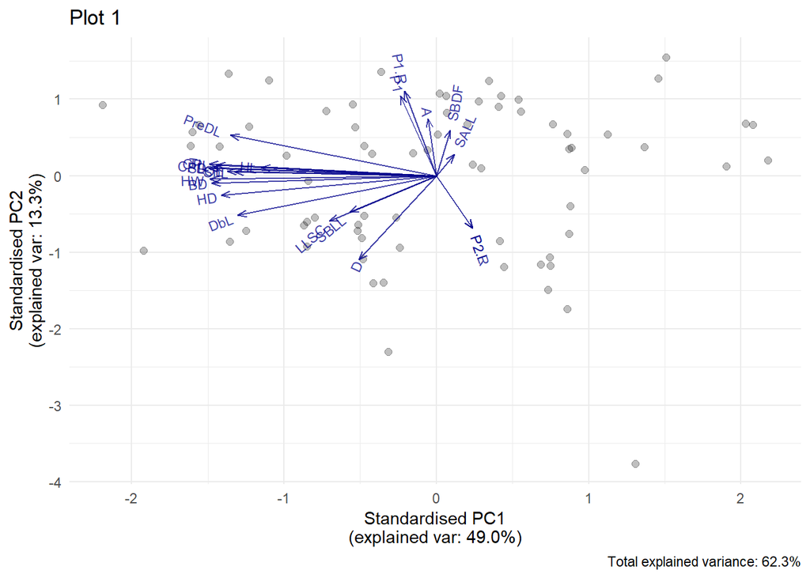

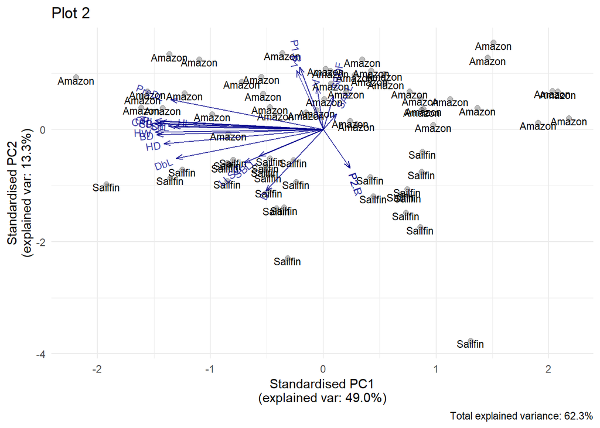

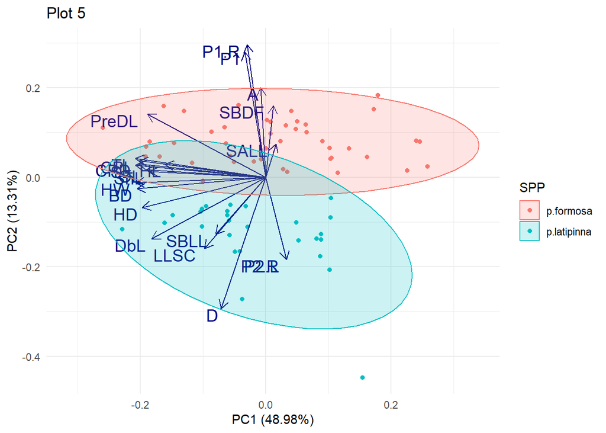

*Variable chart:*

- D: dorsal ray count
- P1: left pectoral ray count
- P2.L: left pelvic rays
- P2.R: right pelvic rays
- A: anal rays
- P1.R: right pectoral ray count
- LLSC: lateral line scale count
- SALL: scales above lateral line
- SBLL: scales below lateral line
- SBDF: scales before dorsal fin
- TL: total length
- SL: standard length
- BD: body depth
- CPD: caudal peduncle depth
- CPL: caudal peduncle length
- PreDL: pre-dorsal length
- DbL: dorsal base length
- HL/HW/HD: head length/width/depth
- SnL: snout length
- OL: ocular length

### Preliminary data inspection

I will first examine the data using box plots to visually assess any major differences. Then I will run t-tests and F-tests between the species for each characteristic to see what differences in means and variences exist *prior to any correction for body size.* At the end of this section, I will present a table with all characteristics, the mean for each species, the variance for each species, and the *p* results for the t- and F-tests.

#### BOX PLOTS

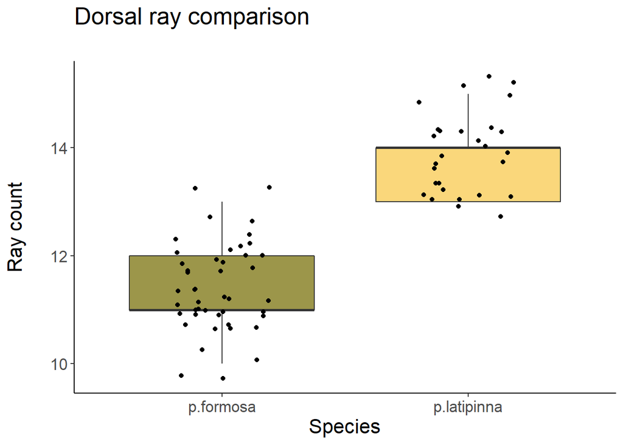

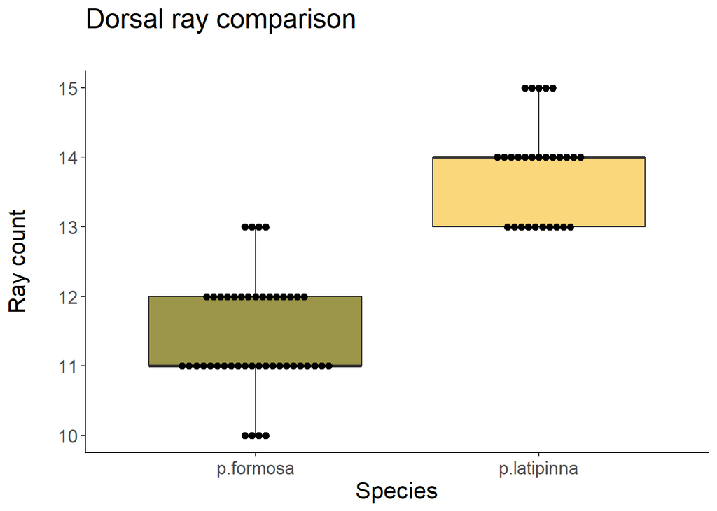

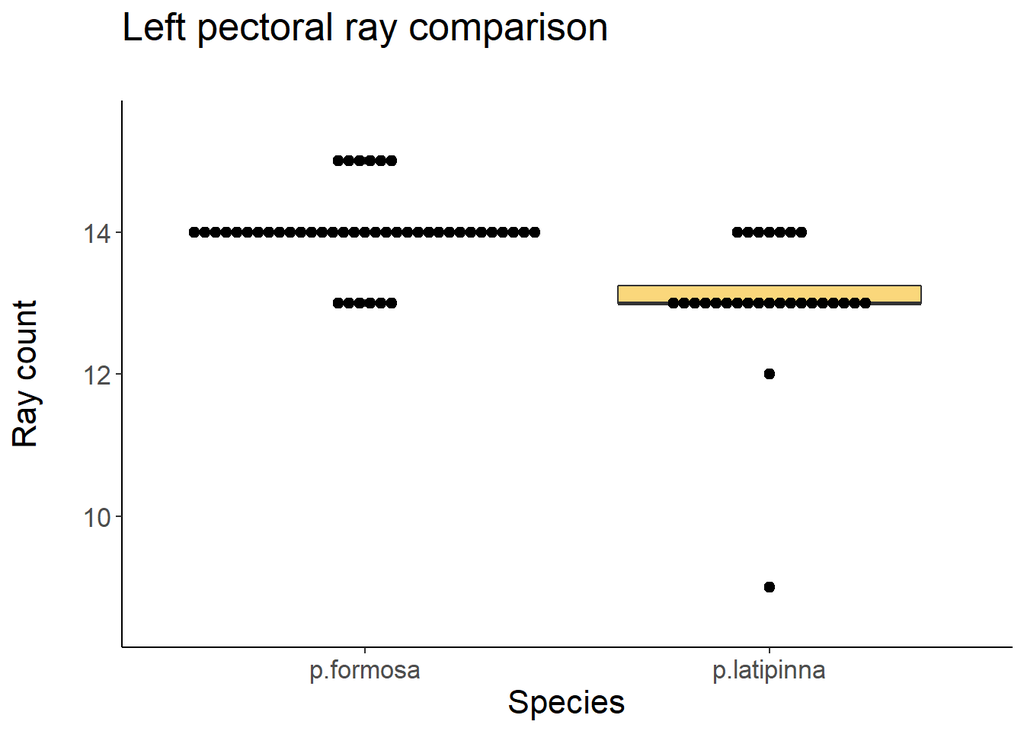

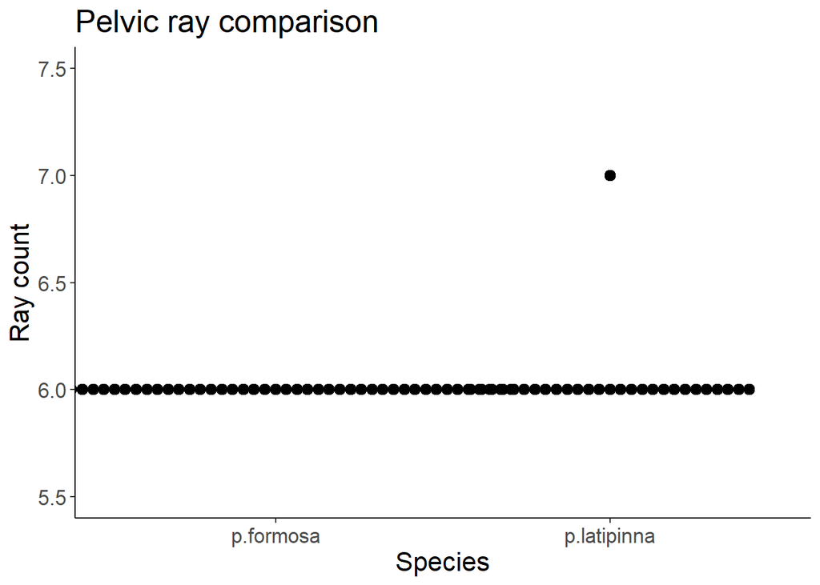

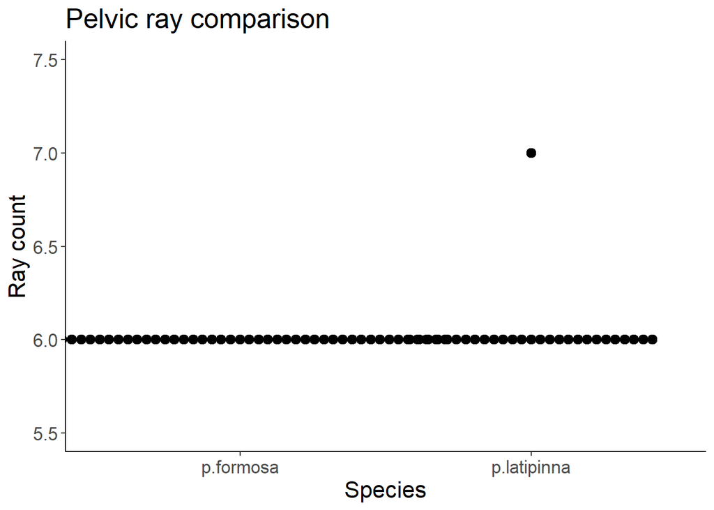

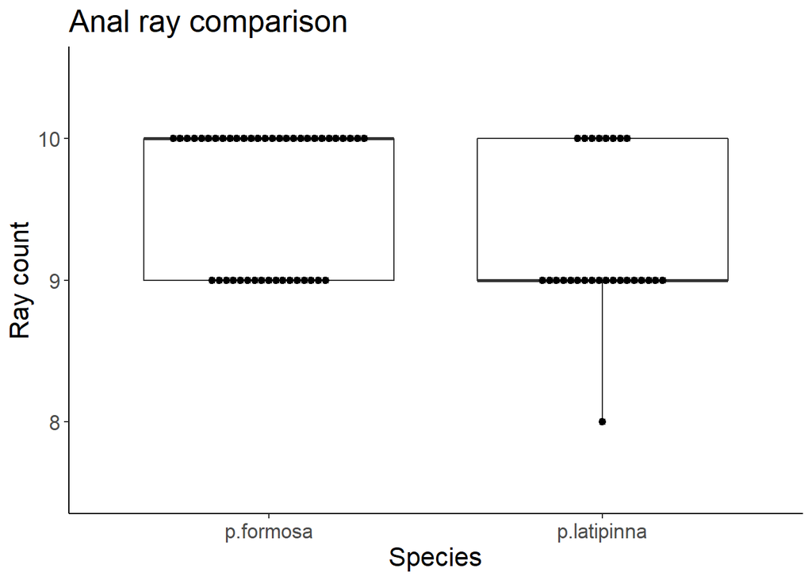

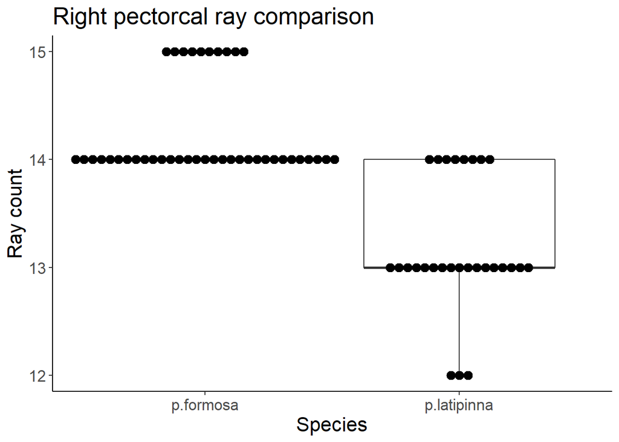

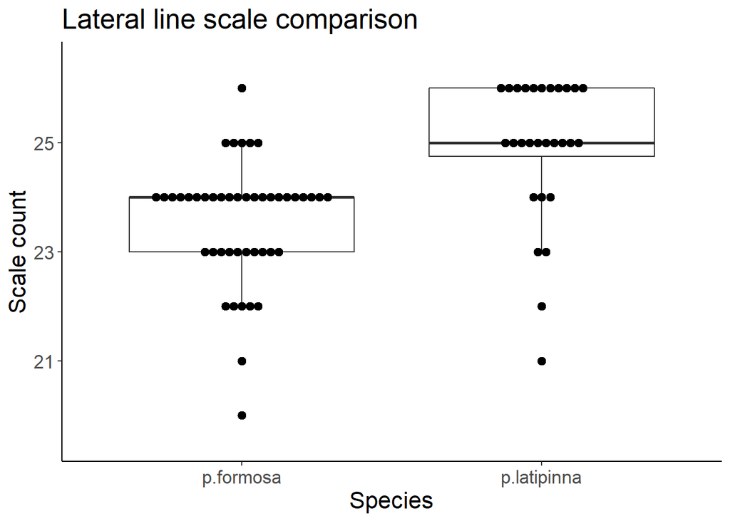

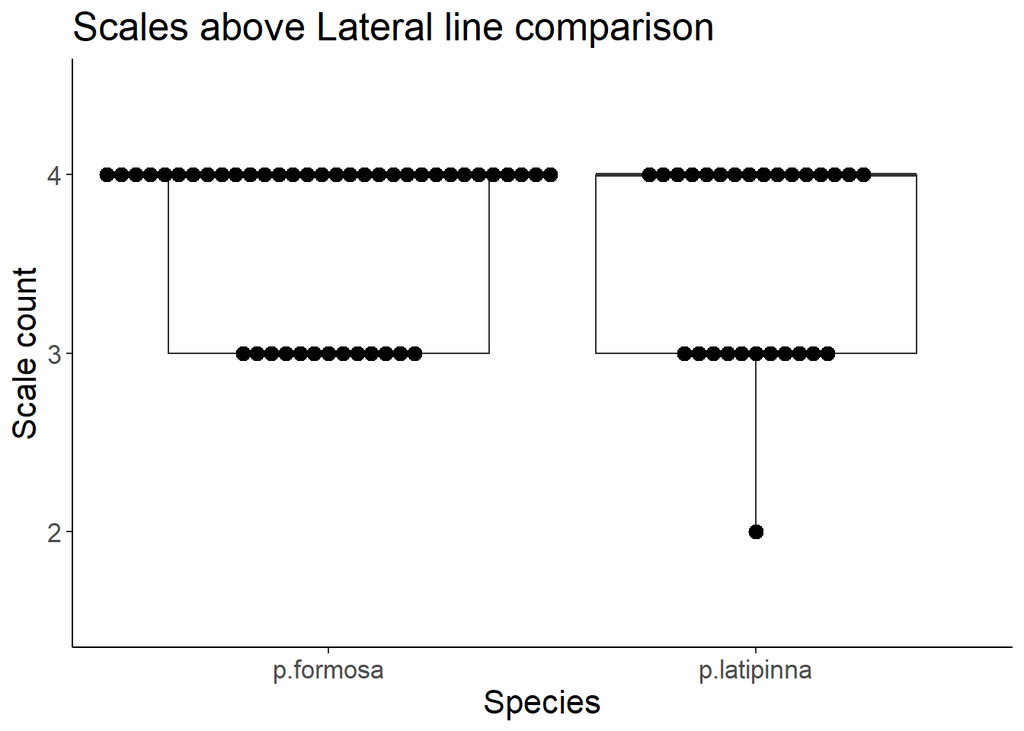

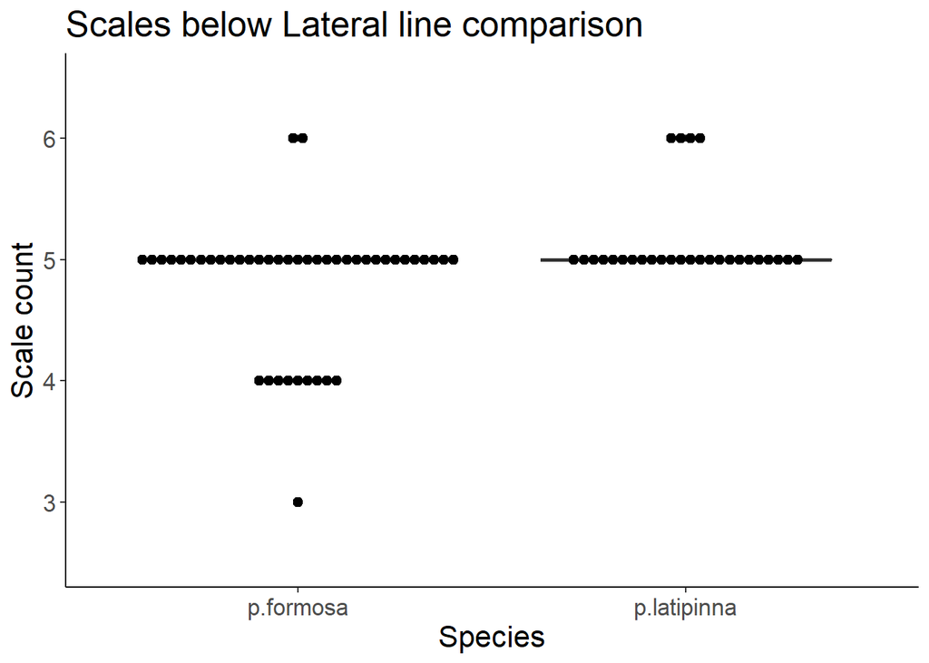

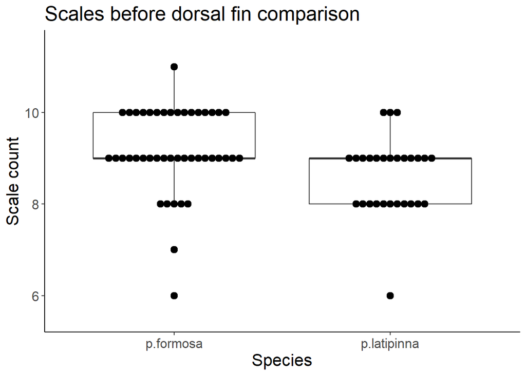

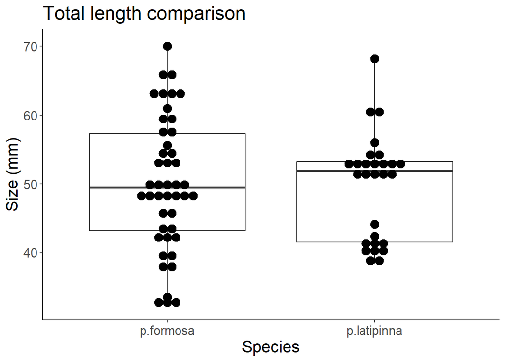

[11 more figures not shown]

#### outliers

*not sure if I should do anymore??* There appear to be some outliers; for example, two points are well below the rest for pectoral count, and upon inspection at least one of these points has the note that the pectoral looks ripped. Will do an outlier test to remove what I can to ensure these outliers are not affecting the significance.

```r
library(DescTools)
```

```r
Outlier(lat$P1, method=c("boxplot"), value = FALSE)
```

```
## [1]  1  2 11 17 18 22 25 27 28
```

- sure enough, the two with ripped notes are popping out as outliers. Will remove and perform stat tests with new dataframe.

```r
lat_pect <- lat[-c(11,17),]



t.test(lat_pect$P1, form$P1, alternative = "two.sided")
```

```
##
##  Welch Two Sample t-test
##
## data:  lat_pect$P1 and form$P1
## t = -6.1915, df = 58.589, p-value = 6.353e-08
## alternative hypothesis: true difference in means is not equal to 0
## 95 percent confidence interval:
##  -0.9669758 -0.4945626
## sample estimates:
## mean of x mean of y
##  13.26923  14.00000
```

```r
t.test(lat_pect$P1, form$P1, alternative = "greater")
```

```
##
##  Welch Two Sample t-test
##
## data:  lat_pect$P1 and form$P1
## t = -6.1915, df = 58.589, p-value = 1
## alternative hypothesis: true difference in means is greater than 0
## 95 percent confidence interval:
##  -0.9280258        Inf
## sample estimates:
## mean of x mean of y
##  13.26923  14.00000
```

```r
var.test(lat_pect$P1, form$P1, alternative = "two.sided")
```

```
##
##  F test to compare two variances
##
## data:  lat_pect$P1 and form$P1
## F = 0.75026, num df = 25, denom df = 44, p-value = 0.4467
## alternative hypothesis: true ratio of variances is not equal to 1
## 95 percent confidence interval:
##  0.3828351 1.5758687
## sample estimates:
## ratio of variances
##          0.7502564
```

- doesn’t look like the variance is significant any more…
- Will check for outliers in all characteristics to see if my stats were a lie…

```r
#latipinna
Outlier(lat$D, method=c("boxplot"), value = FALSE)  #none
```

```
## integer(0)
```

```r
Outlier(lat$P1, method=c("boxplot"), value = FALSE)  #11,17
```

```
## [1]  1  2 11 17 18 22 25 27 28
```

```r
Outlier(lat$P2.L, method=c("boxplot"), value = FALSE)  #none
```

```
## [1] 12
```

```r
Outlier(lat$P2.R, method=c("boxplot"), value = FALSE)  #none
```

```
## [1] 12
```

```r
Outlier(lat$P1.R, method=c("boxplot"), value = FALSE)  #none
```

```
## integer(0)
```

```r
#Outlier(lat$A, method=c("boxplot"), value = FALSE)  #NEED TO REMOVE NAS

Outlier(lat$LLSC, method=c("boxplot"), value = FALSE)  #14,28
```

```
## [1] 14 28
```

```r
lat_LLSC <- lat[-c(14,28),]

Outlier(lat$SALL, method=c("boxplot"), value = FALSE)  #none
```

```
## integer(0)
```

```r
Outlier(lat$SBLL, method=c("boxplot"), value = FALSE)  #none
```

```
## [1] 24 25 26 27
```

```r
Outlier(lat$SBDF, method=c("boxplot"), value = FALSE)  #15
```

```
## [1] 15
```

```r
lat_SBDF <- lat[-c(15),]

Outlier(lat$TL, method=c("boxplot"), value = FALSE)  #none
```

```
## integer(0)
```

```r
Outlier(lat$SL, method=c("boxplot"), value = FALSE)  #none
```

```
## integer(0)
```

```r
Outlier(lat$BD, method=c("boxplot"), value = FALSE)  #none
```

```
## integer(0)
```

```r
Outlier(lat$CPD, method=c("boxplot"), value = FALSE)  #none
```

```
## integer(0)
```

```r
Outlier(lat$CPL, method=c("boxplot"), value = FALSE)  #none
```

```
## [1] 3
```

```r
Outlier(lat$PreDL, method=c("boxplot"), value = FALSE)  #none
```

```
## integer(0)
```

```r
Outlier(lat$DbL, method=c("boxplot"), value = FALSE)  #none
```

```
## integer(0)
```

```r
Outlier(lat$HL, method=c("boxplot"), value = FALSE)  #none
```

```
## [1] 2 3
```

```r
Outlier(lat$HD, method=c("boxplot"), value = FALSE)  #none
```

```
## integer(0)
```

```r
Outlier(lat$HW, method=c("boxplot"), value = FALSE)  #none
```

```
## integer(0)
```

```r
Outlier(lat$SnL, method=c("boxplot"), value = FALSE)  #none
```

```
## integer(0)
```

```r
Outlier(lat$OL, method=c("boxplot"), value = FALSE)  #none
```

```
## integer(0)
```

```r
#formosa

Outlier(form$D, method=c("boxplot"), value = FALSE)  #none
```

```
## integer(0)
```

```r
Outlier(form$P1, method=c("boxplot"), value = FALSE)  #27,31,32,38,39,44
```

```
##  [1]  9 11 14 22 27 30 31 32 33 38 39 44
```

```r
form_pect <- form[-c(27,31,32,38,39,44),]

Outlier(form$P2.L, method=c("boxplot"), value = FALSE)  #none
```

```
## integer(0)
```

```r
Outlier(form$P2.R, method=c("boxplot"), value = FALSE)  #none
```

```
## integer(0)
```

```r
Outlier(form$A, method=c("boxplot"), value = FALSE)  #none
```

```
## integer(0)
```

```r
Outlier(form$P1.R, method=c("boxplot"), value = FALSE) #29,31,32,34
```

```
##  [1]  5  6  9 11 12 14 17 22 29 31 32 34 40 41
```

```r
form_pectR <- form[-c(29,31,32,34),]

Outlier(form$LLSC, method=c("boxplot"), value = FALSE)  #18,31
```

```
## [1] 18 24 31
```

```r
form_LLSC <- form[-c(18,31),]

Outlier(form$SALL, method=c("boxplot"), value = FALSE)  #none
```

```
## integer(0)
```

```r
Outlier(form$SBLL, method=c("boxplot"), value = FALSE)  #10,30,31,32,34,36,37.40.42.43
```

```
##  [1]  9 10 19 30 31 32 34 36 37 40 42 43
```

```r
form_SBLL <- form[-c(10,30,31,32,34,36,37,40,42,43),]

#Outlier(form$SBDF, method=c("boxplot"), value = FALSE)  #NEED TO REMOVE NAS

Outlier(form$TL, method=c("boxplot"), value = FALSE)  #none
```

```
## integer(0)
```

```r
Outlier(form$SL, method=c("boxplot"), value = FALSE)  #none
```

```
## integer(0)
```

```r
Outlier(form$BD, method=c("boxplot"), value = FALSE)  #none
```

```
## integer(0)
```

```r
Outlier(form$CPD, method=c("boxplot"), value = FALSE)  #none
```

```
## integer(0)
```

```r
Outlier(form$CPL, method=c("boxplot"), value = FALSE)  #none
```

```
## integer(0)
```

```r
Outlier(form$PreDL, method=c("boxplot"), value = FALSE)  #nnone
```

```
## integer(0)
```

```r
Outlier(form$DbL, method=c("boxplot"), value = FALSE)  #none
```

```
## integer(0)
```

```r
Outlier(form$HL, method=c("boxplot"), value = FALSE)  #none
```

```
## [1] 16
```

```r
Outlier(form$HD, method=c("boxplot"), value = FALSE)  #none
```

```
## integer(0)
```

```r
Outlier(form$HW, method=c("boxplot"), value = FALSE)  #none
```

```
## integer(0)
```

```r
Outlier(form$SnL, method=c("boxplot"), value = FALSE)  #31
```

```
## [1] 25 31
```

```r
form_SnL <- form[-c(31),]

Outlier(form$OL, method=c("boxplot"), value = FALSE)  #none
```

```
## integer(0)
```

- for latipinna: 11, 17 for P1/ 14, 28 for LLSC/ 15 for SBDF
- for formosa: not making sense. It’s pulling out rows in which the numbers are the same as rows it did not pull out (ex: pulled out 30-32 for SBLL but they all have 5, which is the same value for 26-28 which they did not pull out)
  - turns out the row numbers displayed in the form data table are the row numbers from the original raw table; they don’t correspond to the row numbers highlighted by the outlier function or the tag IDs. Went through and found the correct tag IDs corresponding to outlier rows (see page 45 in lab notebook 3).

#### T.TESTS (outlier removed)

```r
#doral ray counts
t.test(lat$D, form$D, alternative = "two.sided")
```

```
##
##  Welch Two Sample t-test
##
## data:  lat$D and form$D
## t = 13.353, df = 60.9, p-value < 2.2e-16
## alternative hypothesis: true difference in means is not equal to 0
## 95 percent confidence interval:
##  2.039899 2.758513
## sample estimates:
## mean of x mean of y
##  13.82143  11.42222
```

```r
#left pectoral ray counts
t.test(lat_pect$P1, form_pect$P1, alternative = "two.sided")
```

```
##
##  Welch Two Sample t-test
##
## data:  lat_pect$P1 and form_pect$P1
## t = -8.3234, df = 45.793, p-value = 1.026e-10
## alternative hypothesis: true difference in means is not equal to 0
## 95 percent confidence interval:
##  -1.0985730 -0.6706578
## sample estimates:
## mean of x mean of y
##  13.26923  14.15385
```

```r
#left pelvic
t.test(lat$P2.L, form$P2.L, alternative = "two.sided")
```

```
##
##  Welch Two Sample t-test
##
## data:  lat$P2.L and form$P2.L
## t = 1, df = 27, p-value = 0.3262
## alternative hypothesis: true difference in means is not equal to 0
## 95 percent confidence interval:
##  -0.03756538  0.10899395
## sample estimates:
## mean of x mean of y
##  6.035714  6.000000
```

```r
#right pelvic
t.test(lat$P2.R, form$P2.R, alternative = "two.sided")
```

```
##
##  Welch Two Sample t-test
##
## data:  lat$P2.R and form$P2.R
## t = 1, df = 27, p-value = 0.3262
## alternative hypothesis: true difference in means is not equal to 0
## 95 percent confidence interval:
##  -0.03756538  0.10899395
## sample estimates:
## mean of x mean of y
##  6.035714  6.000000
```

```r
#anal ray counts
t.test(lat$A, form$A, alternative = "two.sided")
```

```
##
##  Welch Two Sample t-test
##
## data:  lat$A and form$A
## t = -2.9081, df = 51.874, p-value = 0.005341
## alternative hypothesis: true difference in means is not equal to 0
## 95 percent confidence interval:
##  -0.6134277 -0.1124982
## sample estimates:
## mean of x mean of y
##  9.259259  9.622222
```

```r
#right pectoral ray counts
t.test(lat$P1.R, form_pectR$P1.R, alternative = "two.sided")
```

```
##
##  Welch Two Sample t-test
##
## data:  lat$P1.R and form_pectR$P1.R
## t = -7.945, df = 45.204, p-value = 4.018e-10
## alternative hypothesis: true difference in means is not equal to 0
## 95 percent confidence interval:
##  -1.3353644 -0.7952976
## sample estimates:
## mean of x mean of y
##  13.17857  14.24390
```

```r
#lateral line scale count
t.test(lat_LLSC$LLSC, form_LLSC$LLSC, alternative = "two.sided")
```

```
##
##  Welch Two Sample t-test
##
## data:  lat_LLSC$LLSC and form_LLSC$LLSC
## t = 6.3663, df = 52.363, p-value = 4.927e-08
## alternative hypothesis: true difference in means is not equal to 0
## 95 percent confidence interval:
##  0.9972651 1.9150784
## sample estimates:
## mean of x mean of y
##  25.15385  23.69767
```

```r
#scales above lateral line
t.test(lat$SALL, form$SALL, alternative = "two.sided")
```

```
##
##  Welch Two Sample t-test
##
## data:  lat$SALL and form$SALL
## t = -1.3644, df = 47.892, p-value = 0.1788
## alternative hypothesis: true difference in means is not equal to 0
## 95 percent confidence interval:
##  -0.43388935  0.08309569
## sample estimates:
## mean of x mean of y
##  3.535714  3.711111
```

```r
#scales below lateral line
t.test(lat$SBLL, form_SBLL$SBLL, alternative = "two.sided")
```

```
##
##  Welch Two Sample t-test
##
## data:  lat$SBLL and form_SBLL$SBLL
## t = 1.0957, df = 44.819, p-value = 0.2791
## alternative hypothesis: true difference in means is not equal to 0
## 95 percent confidence interval:
##  -0.07186461  0.24329318
## sample estimates:
## mean of x mean of y
##  5.142857  5.057143
```

```r
#scales before dorsal fin
t.test(lat_SBDF$SBDF, form$SBDF, alternative = "two.sided")
```

```
##
##  Welch Two Sample t-test
##
## data:  lat_SBDF$SBDF and form$SBDF
## t = -2.524, df = 66.946, p-value = 0.01398
## alternative hypothesis: true difference in means is not equal to 0
## 95 percent confidence interval:
##  -0.8562159 -0.1000130
## sample estimates:
## mean of x mean of y
##  8.703704  9.181818
```

```r
#total length
t.test(lat$TL, form$TL, alternative = "two.sided")
```

```
##
##  Welch Two Sample t-test
##
## data:  lat$TL and form$TL
## t = -0.19258, df = 67.141, p-value = 0.8479
## alternative hypothesis: true difference in means is not equal to 0
## 95 percent confidence interval:
##  -4.437475  3.656522
## sample estimates:
## mean of x mean of y
##  49.64286  50.03333
```

```r
#standard length
t.test(lat$SL, form$SL, alternative = "two.sided")
```

```
##
##  Welch Two Sample t-test
##
## data:  lat$SL and form$SL
## t = 0.15719, df = 69.128, p-value = 0.8756
## alternative hypothesis: true difference in means is not equal to 0
## 95 percent confidence interval:
##  -2.817015  3.298920
## sample estimates:
## mean of x mean of y
##  38.41429  38.17333
```

```r
#body depth
t.test(lat$BD, form$BD, alternative = "two.sided")
```

```
##
##  Welch Two Sample t-test
##
## data:  lat$BD and form$BD
## t = 1.7464, df = 69.191, p-value = 0.08519
## alternative hypothesis: true difference in means is not equal to 0
## 95 percent confidence interval:
##  -0.1431642  2.1555452
## sample estimates:
## mean of x mean of y
##  13.49286  12.48667
```

```r
#caudal peduncle depth
t.test(lat$CPD, form$CPD, alternative = "two.sided")
```

```
##
##  Welch Two Sample t-test
##
## data:  lat$CPD and form$CPD
## t = 0.36341, df = 63.14, p-value = 0.7175
## alternative hypothesis: true difference in means is not equal to 0
## 95 percent confidence interval:
##  -0.5676865  0.8200675
## sample estimates:
## mean of x mean of y
##  7.192857  7.066667
```

```r
#caudal peduncle length
t.test(lat$CPL, form$CPL, alternative = "two.sided")
```

```
##
##  Welch Two Sample t-test
##
## data:  lat$CPL and form$CPL
## t = -0.2252, df = 67.31, p-value = 0.8225
## alternative hypothesis: true difference in means is not equal to 0
## 95 percent confidence interval:
##  -1.0856575  0.8654988
## sample estimates:
## mean of x mean of y
##  11.43214  11.54222
```

```r
#pre dorsal length
t.test(lat$PreDL, form$PreDL, alternative = "two.sided")
```

```
##
##  Welch Two Sample t-test
##
## data:  lat$PreDL and form$PreDL
## t = -2.9829, df = 70.883, p-value = 0.003913
## alternative hypothesis: true difference in means is not equal to 0
## 95 percent confidence interval:
##  -3.8810403 -0.7711819
## sample estimates:
## mean of x mean of y
##  19.82500  22.15111
```

```r
#dorsal base length
t.test(lat$DbL, form$DbL, alternative = "two.sided")
```

```
##
##  Welch Two Sample t-test
##
## data:  lat$DbL and form$DbL
## t = 4.9984, df = 53.607, p-value = 6.535e-06
## alternative hypothesis: true difference in means is not equal to 0
## 95 percent confidence interval:
##  1.433109 3.353240
## sample estimates:
## mean of x mean of y
## 10.264286  7.871111
```

```r
#head length
t.test(lat$HL, form$HL, alternative = "two.sided")
```

```
##
##  Welch Two Sample t-test
##
## data:  lat$HL and form$HL
## t = -0.034374, df = 56.553, p-value = 0.9727
## alternative hypothesis: true difference in means is not equal to 0
## 95 percent confidence interval:
##  -0.8184182  0.7907992
## sample estimates:
## mean of x mean of y
##  8.992857  9.006667
```

```r
#head depth
t.test(lat$HD, form$HD, alternative = "two.sided")
```

```
##
##  Welch Two Sample t-test
##
## data:  lat$HD and form$HD
## t = 2.7586, df = 63.336, p-value = 0.00758
## alternative hypothesis: true difference in means is not equal to 0
## 95 percent confidence interval:
##  0.2403307 1.5033201
## sample estimates:
## mean of x mean of y
##  8.960714  8.088889
```

```r
#head width
t.test(lat$HW, form$HW, alternative = "two.sided")
```

```
##
##  Welch Two Sample t-test
##
## data:  lat$HW and form$HW
## t = 1.2301, df = 70.432, p-value = 0.2228
## alternative hypothesis: true difference in means is not equal to 0
## 95 percent confidence interval:
##  -0.2391118  1.0089531
## sample estimates:
## mean of x mean of y
##  7.907143  7.522222
```

```r
#snout length
t.test(lat$SnL, form_SnL$SnL, alternative = "two.sided")
```

```
##
##  Welch Two Sample t-test
##
## data:  lat$SnL and form_SnL$SnL
## t = 0.51629, df = 66.762, p-value = 0.6074
## alternative hypothesis: true difference in means is not equal to 0
## 95 percent confidence interval:
##  -0.1963616  0.3333746
## sample estimates:
## mean of x mean of y
##  3.482143  3.413636
```

```r
#oribital length
t.test(lat$OL, form$OL, alternative = "two.sided")
```

```
##
##  Welch Two Sample t-test
##
## data:  lat$OL and form$OL
## t = 0.07558, df = 67.358, p-value = 0.94
## alternative hypothesis: true difference in means is not equal to 0
## 95 percent confidence interval:
##  -0.2117225  0.2283892
## sample estimates:
## mean of x mean of y
##  3.275000  3.266667
```

#### VARIANCE

```r
lat.var <- apply(lat[8:29], 2, var)
lat.var
```

```
##           D          P1        P2.L        P2.R           A        P1.R
##  0.52248677  0.88359788  0.03571429  0.03571429          NA  0.37433862
##        LLSC        SALL        SBLL        SBDF          TL          SL
##  1.72883598  0.33201058  0.12698413  0.69179894 57.17365079 30.27608466
##          BD         CPD         CPL       PreDL         DbL          HL
##  4.26439153  1.86216931  3.30448413  6.13898148  4.21571429  2.82735450
##          HD          HW         SnL          OL
##  1.53580688  1.16216931  0.24300265  0.16787037
```

```r
form.var <- apply(form[8:29], 2, var)
form.var
```

```
##          D         P1       P2.L       P2.R          A       P1.R       LLSC
##  0.6131313  0.2727273  0.0000000  0.0000000  0.2404040  0.3000000  1.2525253
##       SALL       SBLL       SBDF         TL         SL         BD        CPD
##  0.2101010  0.3000000         NA 93.1204545 57.0833636  8.0848182  2.4331818
##        CPL      PreDL        DbL         HL         HD         HW        SnL
##  5.4411313 17.4980101  3.5402828  2.7188182  2.0264646  2.5385859  0.4348182
##         OL
##  0.2772727
```

#### VARIANCE TESTS (outier removed)

```r
#doral ray counts
var.test(lat$D, form$D, alternative = "two.sided")
```

```
##
##  F test to compare two variances
##
## data:  lat$D and form$D
## F = 0.85216, num df = 27, denom df = 44, p-value = 0.6682
## alternative hypothesis: true ratio of variances is not equal to 1
## 95 percent confidence interval:
##  0.4399533 1.7480314
## sample estimates:
## ratio of variances
##          0.8521613
```

```r
#left pectoral ray counts
var.test(lat_pect$P1, form_pect$P1, alternative = "two.sided")
```

```
##
##  F test to compare two variances
##
## data:  lat_pect$P1 and form_pect$P1
## F = 1.5315, num df = 25, denom df = 38, p-value = 0.2305
## alternative hypothesis: true ratio of variances is not equal to 1
## 95 percent confidence interval:
##  0.7602432 3.2597798
## sample estimates:
## ratio of variances
##           1.531515
```

```r
#left pelvic
var.test(lat$P2.L, form$P2.L, alternative = "two.sided")
```

```
##
##  F test to compare two variances
##
## data:  lat$P2.L and form$P2.L
## F = Inf, num df = 27, denom df = 44, p-value < 2.2e-16
## alternative hypothesis: true ratio of variances is not equal to 1
## 95 percent confidence interval:
##  Inf Inf
## sample estimates:
## ratio of variances
##                Inf
```

```r
#right pelvic
var.test(lat$P2.R, form$P2.R, alternative = "two.sided")
```

```
##
##  F test to compare two variances
##
## data:  lat$P2.R and form$P2.R
## F = Inf, num df = 27, denom df = 44, p-value < 2.2e-16
## alternative hypothesis: true ratio of variances is not equal to 1
## 95 percent confidence interval:
##  Inf Inf
## sample estimates:
## ratio of variances
##                Inf
```

```r
#anal ray counts
var.test(lat$A, form$A, alternative = "two.sided")
```

```
##
##  F test to compare two variances
##
## data:  lat$A and form$A
## F = 1.1495, num df = 26, denom df = 44, p-value = 0.6688
## alternative hypothesis: true ratio of variances is not equal to 1
## 95 percent confidence interval:
##  0.5901254 2.3851290
## sample estimates:
## ratio of variances
##           1.149537
```

```r
#right pectoral ray counts
var.test(lat$P1.R, form_pectR$P1.R, alternative = "two.sided")
```

```
##
##  F test to compare two variances
##
## data:  lat$P1.R and form_pectR$P1.R
## F = 1.9804, num df = 27, denom df = 40, p-value = 0.04856
## alternative hypothesis: true ratio of variances is not equal to 1
## 95 percent confidence interval:
##  1.004368 4.098072
## sample estimates:
## ratio of variances
##           1.980372
```

```r
#lateral line scale count
var.test(lat_LLSC$LLSC, form_LLSC$LLSC, alternative = "two.sided")
```

```
##
##  F test to compare two variances
##
## data:  lat_LLSC$LLSC and form_LLSC$LLSC
## F = 1.0244, num df = 25, denom df = 42, p-value = 0.9224
## alternative hypothesis: true ratio of variances is not equal to 1
## 95 percent confidence interval:
##  0.5183829 2.1604570
## sample estimates:
## ratio of variances
##            1.02442
```

```r
#scales above lateral line
var.test(lat$SALL, form$SALL, alternative = "two.sided")
```

```
##
##  F test to compare two variances
##
## data:  lat$SALL and form$SALL
## F = 1.5802, num df = 27, denom df = 44, p-value = 0.1737
## alternative hypothesis: true ratio of variances is not equal to 1
## 95 percent confidence interval:
##  0.8158466 3.2415388
## sample estimates:
## ratio of variances
##           1.580243
```

```r
#scales below lateral line
var.test(lat$SBLL, form_SBLL$SBLL, alternative = "two.sided")
```

```
##
##  F test to compare two variances
##
## data:  lat$SBLL and form_SBLL$SBLL
## F = 2.2896, num df = 27, denom df = 34, p-value = 0.02311
## alternative hypothesis: true ratio of variances is not equal to 1
## 95 percent confidence interval:
##  1.122262 4.816470
## sample estimates:
## ratio of variances
##           2.289562
```

```r
#scales before dorsal fin
var.test(lat_SBDF$SBDF, form$SBDF, alternative = "two.sided")
```

```
##
##  F test to compare two variances
##
## data:  lat_SBDF$SBDF and form$SBDF
## F = 0.52629, num df = 26, denom df = 43, p-value = 0.08449
## alternative hypothesis: true ratio of variances is not equal to 1
## 95 percent confidence interval:
##  0.2690655 1.0941926
## sample estimates:
## ratio of variances
##           0.526293
```

```r
#total length
var.test(lat$TL, form$TL, alternative = "two.sided")
```

```
##
##  F test to compare two variances
##
## data:  lat$TL and form$TL
## F = 0.61398, num df = 27, denom df = 44, p-value = 0.1801
## alternative hypothesis: true ratio of variances is not equal to 1
## 95 percent confidence interval:
##  0.3169827 1.2594423
## sample estimates:
## ratio of variances
##          0.6139752
```

```r
#standard length
var.test(lat$SL, form$SL, alternative = "two.sided")
```

```
##
##  F test to compare two variances
##
## data:  lat$SL and form$SL
## F = 0.53038, num df = 27, denom df = 44, p-value = 0.0826
## alternative hypothesis: true ratio of variances is not equal to 1
## 95 percent confidence interval:
##  0.2738261 1.0879717
## sample estimates:
## ratio of variances
##          0.5303837
```

```r
#body depth
var.test(lat$BD, form$BD, alternative = "two.sided")
```

```
##
##  F test to compare two variances
##
## data:  lat$BD and form$BD
## F = 0.52746, num df = 27, denom df = 44, p-value = 0.08001
## alternative hypothesis: true ratio of variances is not equal to 1
## 95 percent confidence interval:
##  0.272315 1.081968
## sample estimates:
## ratio of variances
##          0.5274567
```

```r
#caudal peduncle depth
var.test(lat$CPD, form$CPD, alternative = "two.sided")
```

```
##
##  F test to compare two variances
##
## data:  lat$CPD and form$CPD
## F = 0.76532, num df = 27, denom df = 44, p-value = 0.4646
## alternative hypothesis: true ratio of variances is not equal to 1
## 95 percent confidence interval:
##  0.3951203 1.5699002
## sample estimates:
## ratio of variances
##          0.7653227
```

```r
#caudal peduncle length
var.test(lat$CPL, form$CPL, alternative = "two.sided")
```

```
##
##  F test to compare two variances
##
## data:  lat$CPL and form$CPL
## F = 0.60732, num df = 27, denom df = 44, p-value = 0.1706
## alternative hypothesis: true ratio of variances is not equal to 1
## 95 percent confidence interval:
##  0.3135445 1.2457816
## sample estimates:
## ratio of variances
##          0.6073156
```

```r
#pre dorsal length
var.test(lat$PreDL, form$PreDL, alternative = "two.sided")
```

```
##
##  F test to compare two variances
##
## data:  lat$PreDL and form$PreDL
## F = 0.35084, num df = 27, denom df = 44, p-value = 0.004992
## alternative hypothesis: true ratio of variances is not equal to 1
## 95 percent confidence interval:
##  0.1811308 0.7196728
## sample estimates:
## ratio of variances
##          0.3508388
```

```r
#dorsal base length
var.test(lat$DbL, form$DbL, alternative = "two.sided")
```

```
##
##  F test to compare two variances
##
## data:  lat$DbL and form$DbL
## F = 1.1908, num df = 27, denom df = 44, p-value = 0.5945
## alternative hypothesis: true ratio of variances is not equal to 1
## 95 percent confidence interval:
##  0.6147775 2.4426466
## sample estimates:
## ratio of variances
##           1.190785
```

```r
#head length
var.test(lat$HL, form$HL, alternative = "two.sided")
```

```
##
##  F test to compare two variances
##
## data:  lat$HL and form$HL
## F = 1.0399, num df = 27, denom df = 44, p-value = 0.8884
## alternative hypothesis: true ratio of variances is not equal to 1
## 95 percent confidence interval:
##  0.5368894 2.1331801
## sample estimates:
## ratio of variances
##            1.03992
```

```r
#head depth
var.test(lat$HD, form$HD, alternative = "two.sided")
```

```
##
##  F test to compare two variances
##
## data:  lat$HD and form$HD
## F = 0.75787, num df = 27, denom df = 44, p-value = 0.4481
## alternative hypothesis: true ratio of variances is not equal to 1
## 95 percent confidence interval:
##  0.3912752 1.5546227
## sample estimates:
## ratio of variances
##           0.757875
```

```r
#head width
var.test(lat$HW, form$HW, alternative = "two.sided")
```

```
##
##  F test to compare two variances
##
## data:  lat$HW and form$HW
## F = 0.4578, num df = 27, denom df = 44, p-value = 0.03356
## alternative hypothesis: true ratio of variances is not equal to 1
## 95 percent confidence interval:
##  0.2363536 0.9390852
## sample estimates:
## ratio of variances
##          0.4578019
```

```r
#snout length
var.test(lat$SnL, form_SnL$SnL, alternative = "two.sided")
```

```
##
##  F test to compare two variances
##
## data:  lat$SnL and form_SnL$SnL
## F = 0.61859, num df = 27, denom df = 43, p-value = 0.1881
## alternative hypothesis: true ratio of variances is not equal to 1
## 95 percent confidence interval:
##  0.3180394 1.2715208
## sample estimates:
## ratio of variances
##          0.6185902
```

```r
#oribital length
var.test(lat$OL, form$OL, alternative = "two.sided")
```

```
##
##  F test to compare two variances
##
## data:  lat$OL and form$OL
## F = 0.60543, num df = 27, denom df = 44, p-value = 0.168
## alternative hypothesis: true ratio of variances is not equal to 1
## 95 percent confidence interval:
##  0.3125731 1.2419220
## sample estimates:
## ratio of variances
##          0.6054341
```

### Corrections for body size

The amazon mollies are on averages larger than the sailfin mollies, as shown in the t-test above. To ensure body size is not affecting our comparison of these characteristics, I will correct for body size in two main ways: 1) I will run an ANCOVA for each characteristic using standard length (SL) as a covariate. Each model will resemble: trait ~ species * size. This will tell us if the mean differences of the traits are driven by the species or by the body length. 2) To correct for body size with variance, I will regress each trait against SL and use the residuals in the F-test. The original residuals should express both negative and positive values. Additionally, I will run F-tests with the absolute value of the residuals and note any differences in levels of significance (i.e. if it was sig in one but not the other). *need to figure out why doing this was logical again.*

#### ANCOVA

- first I will visualize the regression of each trait against SL for each species to check linearity assumption.

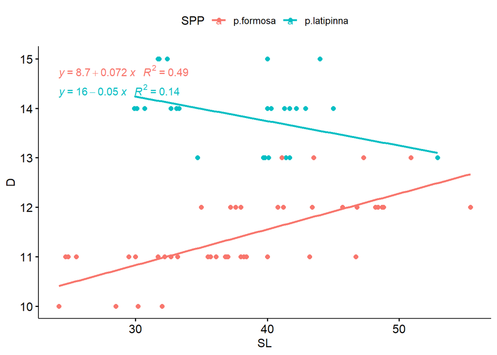

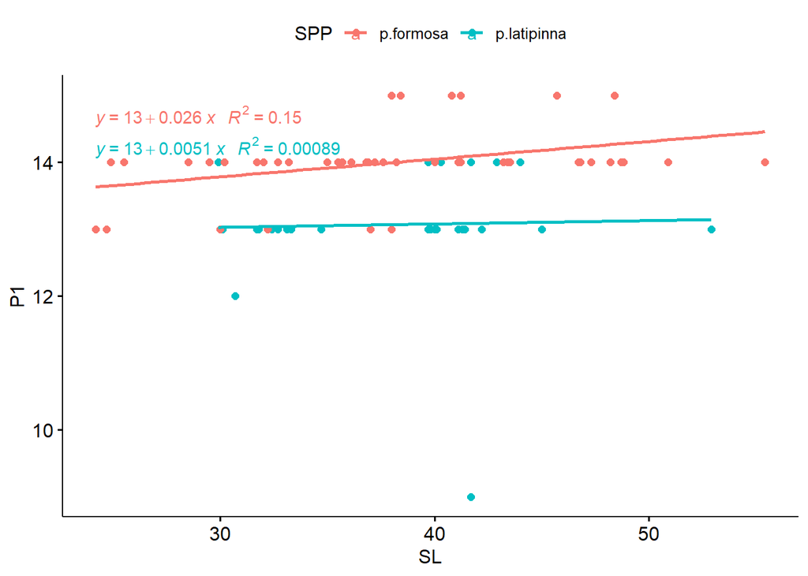

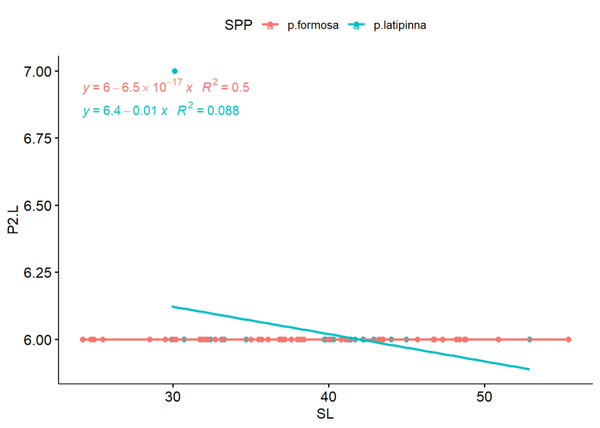

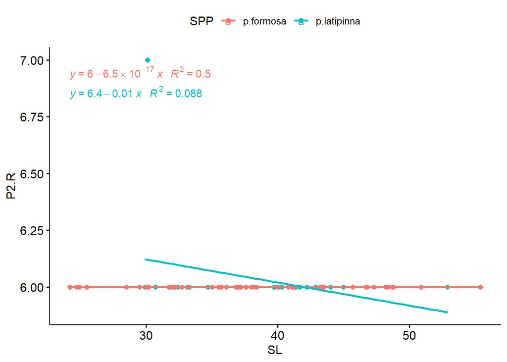

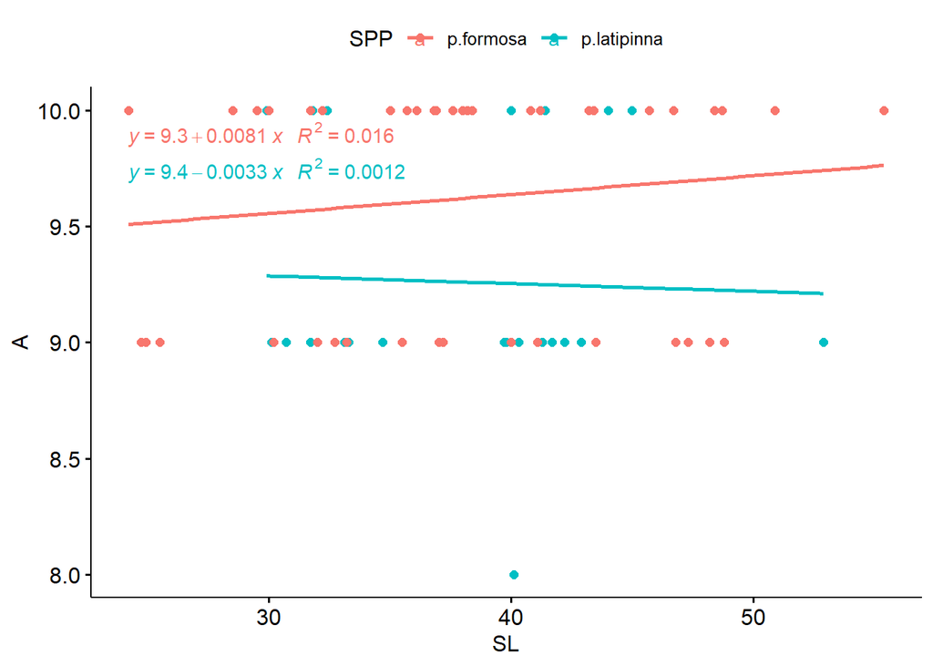

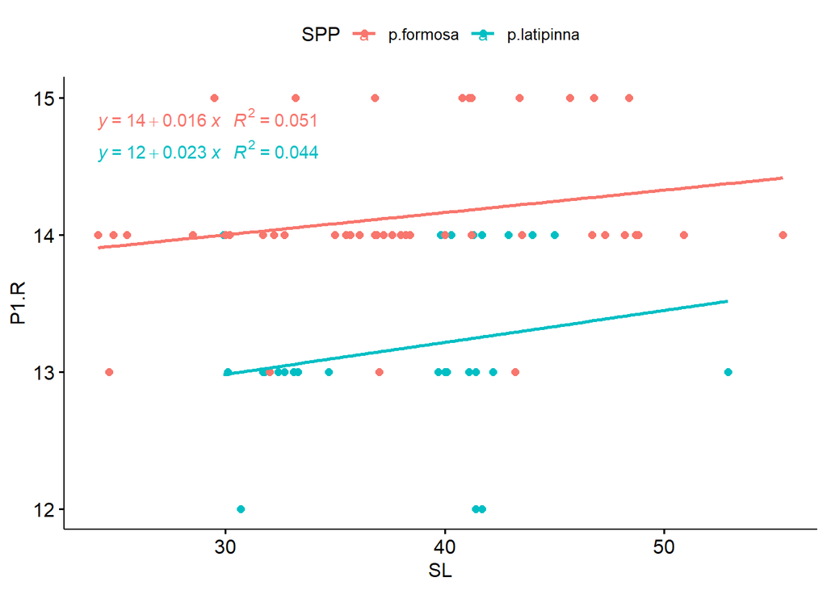

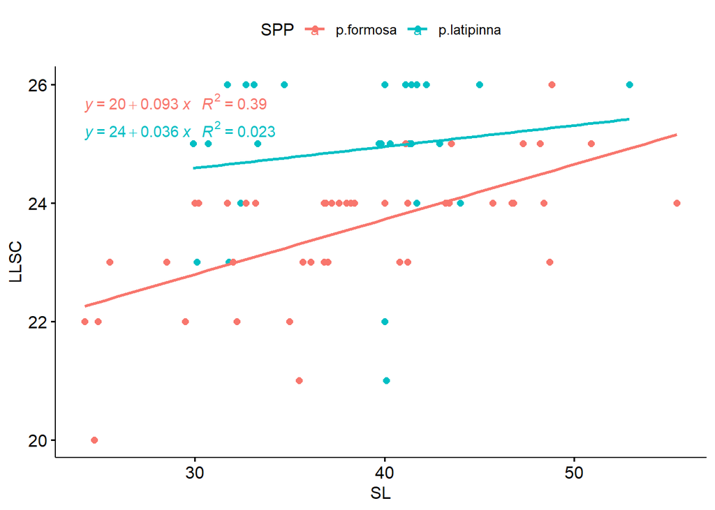

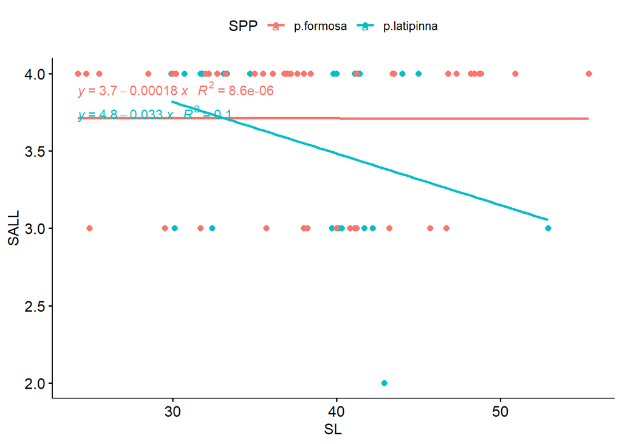

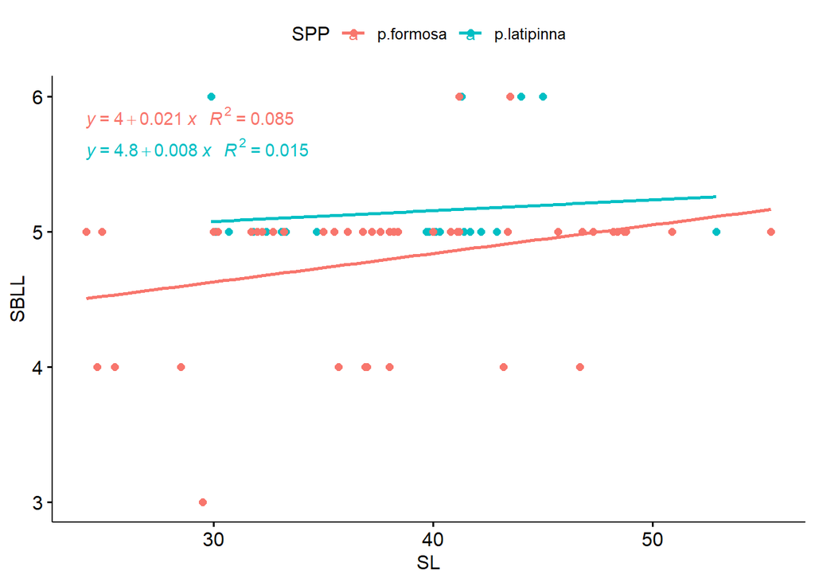

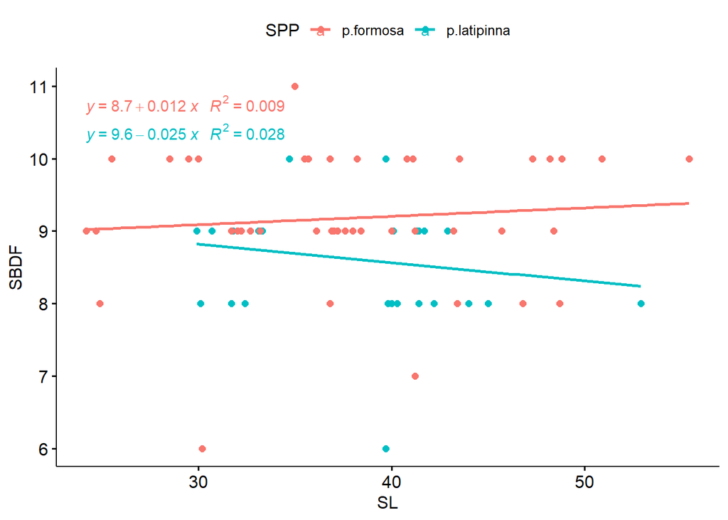

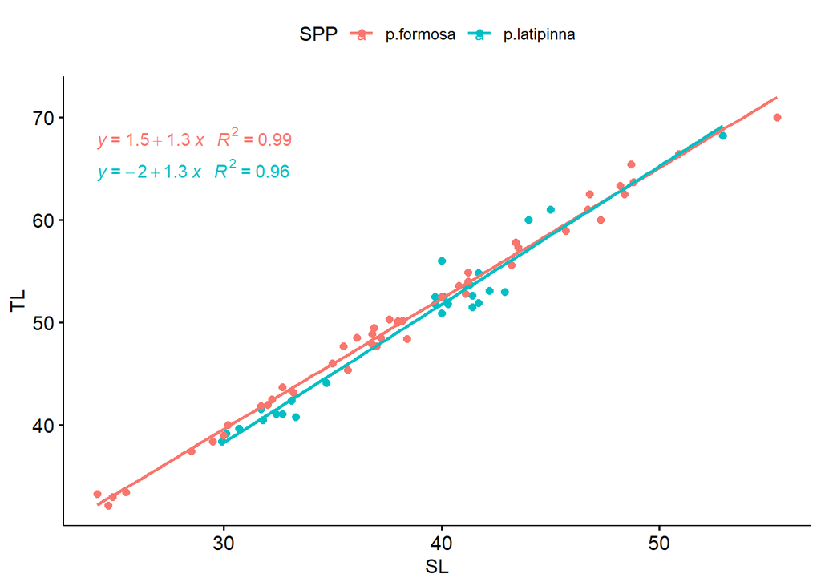

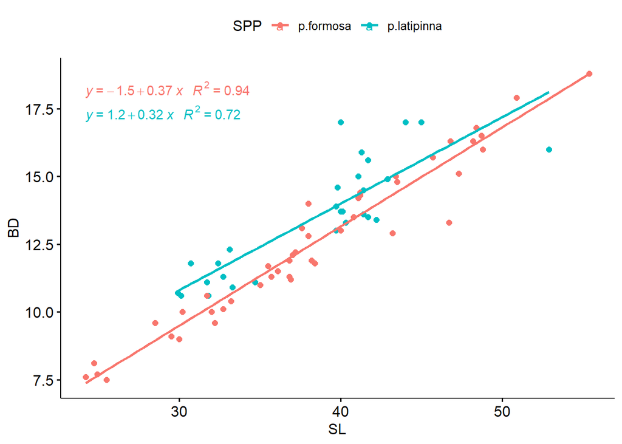

[9 more figures not shown]

```r
Anova(lm(data = raw, TL~SPP*SL))
```

```
## Anova Table (Type II tests)
##
## Response: TL
##           Sum Sq Df   F value  Pr(>F)
## SPP          8.5  1    6.0144 0.01672 *
## SL        5540.3  1 3926.3070 < 2e-16 ***
## SPP:SL       3.3  1    2.3452 0.13025
## Residuals   97.4 69
## ---
## Signif. codes:  0 '***' 0.001 '**' 0.01 '*' 0.05 '.' 0.1 ' ' 1
```

```r
Anova(lm(data = raw, BD ~ SPP * SL))
```

```
## Anova Table (Type II tests)
##
## Response: BD
##           Sum Sq Df  F value    Pr(>F)
## SPP        14.63  1  19.5406 3.577e-05 ***
## SL        417.86  1 558.0862 < 2.2e-16 ***
## SPP:SL      1.34  1   1.7948    0.1847
## Residuals  51.66 69
## ---
## Signif. codes:  0 '***' 0.001 '**' 0.01 '*' 0.05 '.' 0.1 ' ' 1
```

```r
Anova(lm(data = raw, CPD ~ SPP * SL))
```

```
## Anova Table (Type II tests)
##
## Response: CPD
##            Sum Sq Df  F value Pr(>F)
## SPP         0.101  1   0.4669 0.4967
## SL        141.854  1 656.7365 <2e-16 ***
## SPP:SL      0.581  1   2.6908 0.1055
## Residuals  14.904 69
## ---
## Signif. codes:  0 '***' 0.001 '**' 0.01 '*' 0.05 '.' 0.1 ' ' 1
```

```r
Anova(lm(data = raw, CPL ~ SPP * SL))
```

```
## Anova Table (Type II tests)
##
## Response: CPL
##            Sum Sq Df   F value Pr(>F)
## SPP         0.583  1    2.3754 0.1278
## SL        311.430  1 1269.4400 <2e-16 ***
## SPP:SL      0.273  1    1.1144 0.2948
## Residuals  16.928 69
## ---
## Signif. codes:  0 '***' 0.001 '**' 0.01 '*' 0.05 '.' 0.1 ' ' 1
```

```r
Anova(lm(data = raw, PreDL ~ SPP * SL))
```

```
## Anova Table (Type II tests)
##
## Response: PreDL
##           Sum Sq Df  F value    Pr(>F)
## SPP       103.70  1  255.102 < 2.2e-16 ***
## SL        900.95  1 2216.409 < 2.2e-16 ***
## SPP:SL      6.67  1   16.397 0.0001324 ***
## Residuals  28.05 69
## ---
## Signif. codes:  0 '***' 0.001 '**' 0.01 '*' 0.05 '.' 0.1 ' ' 1
```

```r
Anova(lm(data = raw, DbL ~ SPP * SL))
```

```
## Anova Table (Type II tests)
##
## Response: DbL
##            Sum Sq Df  F value    Pr(>F)
## SPP        93.729  1 158.9151 < 2.2e-16 ***
## SL        224.113  1 379.9771 < 2.2e-16 ***
## SPP:SL      4.788  1   8.1173  0.005774 **
## Residuals  40.697 69
## ---
## Signif. codes:  0 '***' 0.001 '**' 0.01 '*' 0.05 '.' 0.1 ' ' 1
```

```r
Anova(lm(data = raw, HL ~ SPP * SL))
```

```
## Anova Table (Type II tests)
##
## Response: HL
##            Sum Sq Df F value    Pr(>F)
## SPP         0.059  1  0.0512    0.8216
## SL        113.674  1 99.2062 5.498e-15 ***
## SPP:SL      3.230  1  2.8186    0.0977 .
## Residuals  79.063 69
## ---
## Signif. codes:  0 '***' 0.001 '**' 0.01 '*' 0.05 '.' 0.1 ' ' 1
```

```r
Anova(lm(data = raw, HD ~ SPP * SL))
```

```
## Anova Table (Type II tests)
##
## Response: HD
##            Sum Sq Df  F value    Pr(>F)
## SPP        11.810  1  49.3436 1.201e-09 ***
## SL        113.579  1 474.5304 < 2.2e-16 ***
## SPP:SL      0.537  1   2.2455    0.1386
## Residuals  16.515 69
## ---
## Signif. codes:  0 '***' 0.001 '**' 0.01 '*' 0.05 '.' 0.1 ' ' 1
```

```r
Anova(lm(data = raw, HW ~ SPP * SL))
```

```
## Anova Table (Type II tests)
##
## Response: HW
##            Sum Sq Df   F value    Pr(>F)
## SPP         1.952  1   17.7920 7.356e-05 ***
## SL        135.160  1 1231.7411 < 2.2e-16 ***
## SPP:SL      0.345  1    3.1429   0.08067 .
## Residuals   7.571 69
## ---
## Signif. codes:  0 '***' 0.001 '**' 0.01 '*' 0.05 '.' 0.1 ' ' 1
```

```r
Anova(lm(data = raw, SnL ~ SPP * SL))
```

```
## Anova Table (Type II tests)
##
## Response: SnL
##            Sum Sq Df  F value  Pr(>F)
## SPP        0.1238  1   1.0890 0.30034
## SL        17.4526  1 153.5450 < 2e-16 ***
## SPP:SL     0.3976  1   3.4984 0.06567 .
## Residuals  7.8428 69
## ---
## Signif. codes:  0 '***' 0.001 '**' 0.01 '*' 0.05 '.' 0.1 ' ' 1
```

```r
Anova(lm(data = raw, OL ~ SPP * SL))
```

```
## Anova Table (Type II tests)
##
## Response: OL
##            Sum Sq Df  F value Pr(>F)
## SPP        0.0008  1   0.0138 0.9070
## SL        12.8822  1 231.8047 <2e-16 ***
## SPP:SL     0.0158  1   0.2841 0.5958
## Residuals  3.8346 69
## ---
## Signif. codes:  0 '***' 0.001 '**' 0.01 '*' 0.05 '.' 0.1 ' ' 1
```

- the only interactions that come out significant are PreDL and DbL
  - this makes sense that there’s an interaction between SPP and SL, since this is a diagnostic characteristic for the species
  - *DO I REMOVE THIS FROM FURTHER ANALYSES?*
- *Unable to perform ANCOVA using the method from https://www.datanovia.com/en/lessons/ancova-in-r/. Not sure what’s going on with the data.*

#### Regression analysis

I will now use residuals to account for body size in each trait, and compare the variance for each species. Again, the first round will take the raw residuals, and the second round with use the absolute value of the raw residuals.

- STEP ONE: plot trait vs body size
- STEP TWO: get residuals for each individual for that trait
- STEP THREE: convert residuals to absolute value
- STEP 4a: perform t and F tests to compare species (raw)
  - just looked at greater (where lat is more variable than form)
  - first, lat>form, then form>lat

```
##
##  F test to compare two variances
##
## data:  res.lat.D and res.form.D
## F = 1.4268, num df = 27, denom df = 44, p-value = 0.1445
## alternative hypothesis: true ratio of variances is greater than 1
## 95 percent confidence interval:
##  0.8197277       Inf
## sample estimates:
## ratio of variances
##           1.426782
```

```
##
##  F test to compare two variances
##
## data:  res.lat.P1 and res.form.P1
## F = 1.5468, num df = 25, denom df = 38, p-value = 0.11
## alternative hypothesis: true ratio of variances is greater than 1
## 95 percent confidence interval:
##  0.8601323       Inf
## sample estimates:
## ratio of variances
##           1.546787
```

```
##
##  F test to compare two variances
##
## data:  res.lat.P2.L and res.form.P2.L
## F = 4.7503e+27, num df = 27, denom df = 44, p-value < 2.2e-16
## alternative hypothesis: true ratio of variances is greater than 1
## 95 percent confidence interval:
##  2.729205e+27          Inf
## sample estimates:
## ratio of variances
##       4.750335e+27
```

```
##
##  F test to compare two variances
##
## data:  res.lat.P2.R and res.form.P2.R
## F = 4.7503e+27, num df = 27, denom df = 44, p-value < 2.2e-16
## alternative hypothesis: true ratio of variances is greater than 1
## 95 percent confidence interval:
##  2.729205e+27          Inf
## sample estimates:
## ratio of variances
##       4.750335e+27
```

```
##
##  F test to compare two variances
##
## data:  res.lat.A and res.form.A
## F = 1.1663, num df = 26, denom df = 44, p-value = 0.3194
## alternative hypothesis: true ratio of variances is greater than 1
## 95 percent confidence interval:
##  0.6668577       Inf
## sample estimates:
## ratio of variances
##           1.166291
```

```
##
##  F test to compare two variances
##
## data:  res.lat.P1.R and res.form.P1.R
## F = 1.9453, num df = 27, denom df = 40, p-value = 0.02735
## alternative hypothesis: true ratio of variances is greater than 1
## 95 percent confidence interval:
##  1.101328      Inf
## sample estimates:
## ratio of variances
##           1.945319
```

```
##
##  F test to compare two variances
##
## data:  res.lat.LLSC and res.form.LLSC
## F = 1.49, num df = 25, denom df = 42, p-value = 0.1244
## alternative hypothesis: true ratio of variances is greater than 1
## 95 percent confidence interval:
##  0.8417808       Inf
## sample estimates:
## ratio of variances
##           1.489995
```

```
##
##  F test to compare two variances
##
## data:  res.lat.SALL and res.form.SALL
## F = 1.4205, num df = 27, denom df = 44, p-value = 0.1474
## alternative hypothesis: true ratio of variances is greater than 1
## 95 percent confidence interval:
##  0.8161429       Inf
## sample estimates:
## ratio of variances
##           1.420543
```

```
##
##  F test to compare two variances
##
## data:  res.lat.SBLL and res.form.SBLL
## F = 2.2804, num df = 27, denom df = 34, p-value = 0.01189
## alternative hypothesis: true ratio of variances is greater than 1
## 95 percent confidence interval:
##  1.255248      Inf
## sample estimates:
## ratio of variances
##           2.280398
```

```
##
##  F test to compare two variances
##
## data:  res.lat.SBDF and res.form.SBDF
## F = 0.51417, num df = 26, denom df = 43, p-value = 0.963
## alternative hypothesis: true ratio of variances is greater than 1
## 95 percent confidence interval:
##  0.2929929       Inf
## sample estimates:
## ratio of variances
##          0.5141725
```

```
##
##  F test to compare two variances
##
## data:  res.lat.TL and res.form.TL
## F = 3.1589, num df = 27, denom df = 44, p-value = 0.0003436
## alternative hypothesis: true ratio of variances is greater than 1
## 95 percent confidence interval:
##  1.814878      Inf
## sample estimates:
## ratio of variances
##           3.158897
```

```
##
##  F test to compare two variances
##
## data:  res.lat.BD and res.form.BD
## F = 2.6344, num df = 27, denom df = 44, p-value = 0.002087
## alternative hypothesis: true ratio of variances is greater than 1
## 95 percent confidence interval:
##  1.513535      Inf
## sample estimates:
## ratio of variances
##           2.634392
```

```
##
##  F test to compare two variances
##
## data:  res.lat.CPD and res.form.CPD
## F = 1.5199, num df = 27, denom df = 44, p-value = 0.1064
## alternative hypothesis: true ratio of variances is greater than 1
## 95 percent confidence interval:
##  0.8732155       Inf
## sample estimates:
## ratio of variances
##           1.519881
```

```
##
##  F test to compare two variances
##
## data:  res.lat.CPL and res.form.CPL
## F = 0.60833, num df = 27, denom df = 44, p-value = 0.914
## alternative hypothesis: true ratio of variances is greater than 1
## 95 percent confidence interval:
##  0.3495041       Inf
## sample estimates:
## ratio of variances
##          0.6083316
```

```
##
##  F test to compare two variances
##
## data:  res.lat.PreDL and res.form.PreDL
## F = 0.46302, num df = 27, denom df = 44, p-value = 0.9819
## alternative hypothesis: true ratio of variances is greater than 1
## 95 percent confidence interval:
##  0.2660158       Inf
## sample estimates:
## ratio of variances
##          0.4630155
```

```
##
##  F test to compare two variances
##
## data:  res.lat.DbL and res.form.DbL
## F = 3.2072, num df = 27, denom df = 44, p-value = 0.0002923
## alternative hypothesis: true ratio of variances is greater than 1
## 95 percent confidence interval:
##  1.842601      Inf
## sample estimates:
## ratio of variances
##           3.207151
```

```
##
##  F test to compare two variances
##
## data:  res.lat.HL and res.form.HL
## F = 0.96975, num df = 27, denom df = 44, p-value = 0.5241
## alternative hypothesis: true ratio of variances is greater than 1
## 95 percent confidence interval:
##  0.5571472       Inf
## sample estimates:
## ratio of variances
##           0.969746
```

```
##
##  F test to compare two variances
##
## data:  res.lat.HD and res.form.HD
## F = 1.0435, num df = 27, denom df = 44, p-value = 0.4403
## alternative hypothesis: true ratio of variances is greater than 1
## 95 percent confidence interval:
##  0.5995072       Inf
## sample estimates:
## ratio of variances
##           1.043476
```

```
##
##  F test to compare two variances
##
## data:  res.lat.HW and res.form.HW
## F = 1.6484, num df = 27, denom df = 44, p-value = 0.06882
## alternative hypothesis: true ratio of variances is greater than 1
## 95 percent confidence interval:
##  0.9470651       Inf
## sample estimates:
## ratio of variances
##            1.64842
```

```
##
##  F test to compare two variances
##
## data:  res.lat.SnL and res.form.SnL
## F = 1.9852, num df = 27, denom df = 43, p-value = 0.0217
## alternative hypothesis: true ratio of variances is greater than 1
## 95 percent confidence interval:
##  1.136628      Inf
## sample estimates:
## ratio of variances
##            1.98517
```

```
##
##  F test to compare two variances
##
## data:  res.lat.OL and res.form.OL
## F = 1.3618, num df = 27, denom df = 44, p-value = 0.1778
## alternative hypothesis: true ratio of variances is greater than 1
## 95 percent confidence interval:
##  0.7823867       Inf
## sample estimates:
## ratio of variances
##           1.361788
```

```
##
##  F test to compare two variances
##
## data:  res.lat.D and res.form.D
## F = 1.4268, num df = 27, denom df = 44, p-value = 0.8555
## alternative hypothesis: true ratio of variances is less than 1
## 95 percent confidence interval:
##  0.000000 2.600358
## sample estimates:
## ratio of variances
##           1.426782
```

```
##
##  F test to compare two variances
##
## data:  res.lat.P1 and res.form.P1
## F = 1.5468, num df = 25, denom df = 38, p-value = 0.89
## alternative hypothesis: true ratio of variances is less than 1
## 95 percent confidence interval:
##  0.000000 2.907107
## sample estimates:
## ratio of variances
##           1.546787
```

```
##
##  F test to compare two variances
##
## data:  res.lat.P2.L and res.form.P2.L
## F = 4.7503e+27, num df = 27, denom df = 44, p-value = 1
## alternative hypothesis: true ratio of variances is less than 1
## 95 percent confidence interval:
##  0.000000e+00 8.657643e+27
## sample estimates:
## ratio of variances
##       4.750335e+27
```

```
##
##  F test to compare two variances
##
## data:  res.lat.P2.R and res.form.P2.R
## F = 4.7503e+27, num df = 27, denom df = 44, p-value = 1
## alternative hypothesis: true ratio of variances is less than 1
## 95 percent confidence interval:
##  0.000000e+00 8.657643e+27
## sample estimates:
## ratio of variances
##       4.750335e+27
```

```
##
##  F test to compare two variances
##
## data:  res.lat.A and res.form.A
## F = 1.1663, num df = 26, denom df = 44, p-value = 0.6806
## alternative hypothesis: true ratio of variances is less than 1
## 95 percent confidence interval:
##  0.000000 2.145706
## sample estimates:
## ratio of variances
##           1.166291
```

```
##
##  F test to compare two variances
##
## data:  res.lat.P1.R and res.form.P1.R
## F = 1.9453, num df = 27, denom df = 40, p-value = 0.9727
## alternative hypothesis: true ratio of variances is less than 1
## 95 percent confidence interval:
##  0.000000 3.571855
## sample estimates:
## ratio of variances
##           1.945319
```

```
##
##  F test to compare two variances
##
## data:  res.lat.LLSC and res.form.LLSC
## F = 1.49, num df = 25, denom df = 42, p-value = 0.8756
## alternative hypothesis: true ratio of variances is less than 1
## 95 percent confidence interval:
##  0.000000 2.778577
## sample estimates:
## ratio of variances
##           1.489995
```

```
##
##  F test to compare two variances
##
## data:  res.lat.SALL and res.form.SALL
## F = 1.4205, num df = 27, denom df = 44, p-value = 0.8526
## alternative hypothesis: true ratio of variances is less than 1
## 95 percent confidence interval:
##  0.000000 2.588986
## sample estimates:
## ratio of variances
##           1.420543
```

```
##
##  F test to compare two variances
##
## data:  res.lat.SBLL and res.form.SBLL
## F = 2.2804, num df = 27, denom df = 34, p-value = 0.9881
## alternative hypothesis: true ratio of variances is less than 1
## 95 percent confidence interval:
##  0.000000 4.245923
## sample estimates:
## ratio of variances
##           2.280398
```

```
##
##  F test to compare two variances
##
## data:  res.lat.SBDF and res.form.SBDF
## F = 0.51417, num df = 26, denom df = 43, p-value = 0.03703
## alternative hypothesis: true ratio of variances is less than 1
## 95 percent confidence interval:
##  0.0000000 0.9475812
## sample estimates:
## ratio of variances
##          0.5141725
```

```
##
##  F test to compare two variances
##
## data:  res.lat.TL and res.form.TL
## F = 3.1589, num df = 27, denom df = 44, p-value = 0.9997
## alternative hypothesis: true ratio of variances is less than 1
## 95 percent confidence interval:
##  0.000000 5.757194
## sample estimates:
## ratio of variances
##           3.158897
```

```
##
##  F test to compare two variances
##
## data:  res.lat.BD and res.form.BD
## F = 2.6344, num df = 27, denom df = 44, p-value = 0.9979
## alternative hypothesis: true ratio of variances is less than 1
## 95 percent confidence interval:
##  0.000000 4.801267
## sample estimates:
## ratio of variances
##           2.634392
```

```
##
##  F test to compare two variances
##
## data:  res.lat.CPD and res.form.CPD
## F = 1.5199, num df = 27, denom df = 44, p-value = 0.8936
## alternative hypothesis: true ratio of variances is less than 1
## 95 percent confidence interval:
##  0.000000 2.770033
## sample estimates:
## ratio of variances
##           1.519881
```

```
##
##  F test to compare two variances
##
## data:  res.lat.CPL and res.form.CPL
## F = 0.60833, num df = 27, denom df = 44, p-value = 0.08603
## alternative hypothesis: true ratio of variances is less than 1
## 95 percent confidence interval:
##  0.000000 1.108705
## sample estimates:
## ratio of variances
##          0.6083316
```

```
##
##  F test to compare two variances
##
## data:  res.lat.PreDL and res.form.PreDL
## F = 0.46302, num df = 27, denom df = 44, p-value = 0.01806
## alternative hypothesis: true ratio of variances is less than 1
## 95 percent confidence interval:
##  0.0000000 0.8438611
## sample estimates:
## ratio of variances
##          0.4630155
```

```
##
##  F test to compare two variances
##
## data:  res.lat.DbL and res.form.DbL
## F = 3.2072, num df = 27, denom df = 44, p-value = 0.9997
## alternative hypothesis: true ratio of variances is less than 1
## 95 percent confidence interval:
##  0.000000 5.845138
## sample estimates:
## ratio of variances
##           3.207151
```

```
##
##  F test to compare two variances
##
## data:  res.lat.HL and res.form.HL
## F = 0.96975, num df = 27, denom df = 44, p-value = 0.4759
## alternative hypothesis: true ratio of variances is less than 1
## 95 percent confidence interval:
##  0.000000 1.767394
## sample estimates:
## ratio of variances
##           0.969746
```

```
##
##  F test to compare two variances
##
## data:  res.lat.HD and res.form.HD
## F = 1.0435, num df = 27, denom df = 44, p-value = 0.5597
## alternative hypothesis: true ratio of variances is less than 1
## 95 percent confidence interval:
##  0.00000 1.90177
## sample estimates:
## ratio of variances
##           1.043476
```

```
##
##  F test to compare two variances
##
## data:  res.lat.HW and res.form.HW
## F = 1.6484, num df = 27, denom df = 44, p-value = 0.9312
## alternative hypothesis: true ratio of variances is less than 1
## 95 percent confidence interval:
##  0.0000 3.0043
## sample estimates:
## ratio of variances
##            1.64842
```

```
##
##  F test to compare two variances
##
## data:  res.lat.SnL and res.form.SnL
## F = 1.9852, num df = 27, denom df = 43, p-value = 0.9783
## alternative hypothesis: true ratio of variances is less than 1
## 95 percent confidence interval:
##  0.000000 3.624354
## sample estimates:
## ratio of variances
##            1.98517
```

```
##
##  F test to compare two variances
##
## data:  res.lat.OL and res.form.OL
## F = 1.3618, num df = 27, denom df = 44, p-value = 0.8222
## alternative hypothesis: true ratio of variances is less than 1
## 95 percent confidence interval:
##  0.000000 2.481904
## sample estimates:
## ratio of variances
##           1.361788
```

- STEP 4b: will compare variances with absolute value of residuals and mark which ones produce an alternative p-value
  - first lat>form, then form>lat

```
##
##  F test to compare two variances
##
## data:  abs.lat.D and abs.form.D
## F = 1.2282, num df = 27, denom df = 44, p-value = 0.2669
## alternative hypothesis: true ratio of variances is greater than 1
## 95 percent confidence interval:
##  0.7056353       Inf
## sample estimates:
## ratio of variances
##           1.228198
```

```
##
##  F test to compare two variances
##
## data:  abs.lat.P1 and abs.form.P1
## F = 0.71265, num df = 25, denom df = 38, p-value = 0.8119
## alternative hypothesis: true ratio of variances is greater than 1
## 95 percent confidence interval:
##  0.3962861       Inf
## sample estimates:
## ratio of variances
##          0.7126462
```

```
##
##  F test to compare two variances
##
## data:  abs.lat.P2.L and abs.form.P2.L
## F = 4.3767e+27, num df = 27, denom df = 44, p-value < 2.2e-16
## alternative hypothesis: true ratio of variances is greater than 1
## 95 percent confidence interval:
##  2.514548e+27          Inf
## sample estimates:
## ratio of variances
##       4.376712e+27
```

```
##
##  F test to compare two variances
##
## data:  abs.lat.P2.R and abs.form.P2.R
## F = 4.3767e+27, num df = 27, denom df = 44, p-value < 2.2e-16
## alternative hypothesis: true ratio of variances is greater than 1
## 95 percent confidence interval:
##  2.514548e+27          Inf
## sample estimates:
## ratio of variances
##       4.376712e+27
```

```
##
##  F test to compare two variances
##
## data:  abs.lat.A and abs.form.A
## F = 4.3234, num df = 26, denom df = 44, p-value = 9.904e-06
## alternative hypothesis: true ratio of variances is greater than 1
## 95 percent confidence interval:
##  2.472014      Inf
## sample estimates:
## ratio of variances
##           4.323392
```

```
##
##  F test to compare two variances
##
## data:  abs.lat.P1.R and abs.form.P1.R
## F = 3.0079, num df = 27, denom df = 40, p-value = 0.0007899
## alternative hypothesis: true ratio of variances is greater than 1
## 95 percent confidence interval:
##  1.702902      Inf
## sample estimates:
## ratio of variances
##           3.007904
```

```
##
##  F test to compare two variances
##
## data:  abs.lat.LLSC and abs.form.LLSC
## F = 1.7432, num df = 25, denom df = 42, p-value = 0.05467
## alternative hypothesis: true ratio of variances is greater than 1
## 95 percent confidence interval:
##  0.9848187       Inf
## sample estimates:
## ratio of variances
##           1.743179
```

```
##
##  F test to compare two variances
##
## data:  abs.lat.SALL and abs.form.SALL
## F = 1.6801, num df = 27, denom df = 44, p-value = 0.0617
## alternative hypothesis: true ratio of variances is greater than 1
## 95 percent confidence interval:
##  0.965256      Inf
## sample estimates:
## ratio of variances
##           1.680082
```

```
##
##  F test to compare two variances
##
## data:  abs.lat.SBLL and abs.form.SBLL
## F = 1.5002, num df = 27, denom df = 34, p-value = 0.1309
## alternative hypothesis: true ratio of variances is greater than 1
## 95 percent confidence interval:
##  0.8257717       Inf
## sample estimates:
## ratio of variances
##           1.500172
```

```
##
##  F test to compare two variances
##
## data:  abs.lat.SBDF and abs.form.SBDF
## F = 0.31809, num df = 26, denom df = 43, p-value = 0.9986
## alternative hypothesis: true ratio of variances is greater than 1
## 95 percent confidence interval:
##  0.1812609       Inf
## sample estimates:
## ratio of variances
##          0.3180943
```

```
##
##  F test to compare two variances
##
## data:  abs.lat.TL and abs.form.TL
## F = 3.3854, num df = 27, denom df = 44, p-value = 0.000162
## alternative hypothesis: true ratio of variances is greater than 1
## 95 percent confidence interval:
##  1.945023      Inf
## sample estimates:
## ratio of variances
##           3.385423
```

```
##
##  F test to compare two variances
##
## data:  abs.lat.BD and abs.form.BD
## F = 2.5758, num df = 27, denom df = 44, p-value = 0.002564
## alternative hypothesis: true ratio of variances is greater than 1
## 95 percent confidence interval:
##  1.479895      Inf
## sample estimates:
## ratio of variances
##            2.57584
```

```
##
##  F test to compare two variances
##
## data:  abs.lat.CPD and abs.form.CPD
## F = 1.4357, num df = 27, denom df = 44, p-value = 0.1404
## alternative hypothesis: true ratio of variances is greater than 1
## 95 percent confidence interval:
##  0.8248509       Inf
## sample estimates:
## ratio of variances
##           1.435699
```

```
##
##  F test to compare two variances
##
## data:  abs.lat.CPL and abs.form.CPL
## F = 0.71163, num df = 27, denom df = 44, p-value = 0.8249
## alternative hypothesis: true ratio of variances is greater than 1
## 95 percent confidence interval:
##  0.4088508       Inf
## sample estimates:
## ratio of variances
##          0.7116279
```

```
##
##  F test to compare two variances
##
## data:  abs.lat.PreDL and abs.form.PreDL
## F = 0.38399, num df = 27, denom df = 44, p-value = 0.9951
## alternative hypothesis: true ratio of variances is greater than 1
## 95 percent confidence interval:
##  0.2206108       Inf
## sample estimates:
## ratio of variances
##          0.3839856
```

```
##
##  F test to compare two variances
##
## data:  abs.lat.DbL and abs.form.DbL
## F = 4.9709, num df = 27, denom df = 44, p-value = 1.367e-06
## alternative hypothesis: true ratio of variances is greater than 1
## 95 percent confidence interval:
##  2.855943      Inf
## sample estimates:
## ratio of variances
##           4.970929
```

```
##
##  F test to compare two variances
##
## data:  abs.lat.HL and abs.form.HL
## F = 1.4404, num df = 27, denom df = 44, p-value = 0.1383
## alternative hypothesis: true ratio of variances is greater than 1
## 95 percent confidence interval:
##  0.8275468       Inf
## sample estimates:
## ratio of variances
##           1.440392
```

```
##
##  F test to compare two variances
##
## data:  abs.lat.HD and abs.form.HD
## F = 0.94239, num df = 27, denom df = 44, p-value = 0.5566
## alternative hypothesis: true ratio of variances is greater than 1
## 95 percent confidence interval:
##  0.5414331       Inf
## sample estimates:
## ratio of variances
##          0.9423947
```

```
##
##  F test to compare two variances
##
## data:  abs.lat.HW and abs.form.HW
## F = 1.7135, num df = 27, denom df = 44, p-value = 0.05494
## alternative hypothesis: true ratio of variances is greater than 1
## 95 percent confidence interval:
##  0.9844569       Inf
## sample estimates:
## ratio of variances
##           1.713503
```

```
##
##  F test to compare two variances
##
## data:  abs.lat.SnL and abs.form.SnL
## F = 2.3116, num df = 27, denom df = 43, p-value = 0.006852
## alternative hypothesis: true ratio of variances is greater than 1
## 95 percent confidence interval:
##  1.323514      Inf
## sample estimates:
## ratio of variances
##           2.311576
```

```
##
##  F test to compare two variances
##
## data:  abs.lat.OL and abs.form.OL
## F = 1.0247, num df = 27, denom df = 44, p-value = 0.4611
## alternative hypothesis: true ratio of variances is greater than 1
## 95 percent confidence interval:
##  0.5886991       Inf
## sample estimates:
## ratio of variances
##           1.024664
```

```
##
##  F test to compare two variances
##
## data:  abs.lat.D and abs.form.D
## F = 1.2282, num df = 27, denom df = 44, p-value = 0.7331
## alternative hypothesis: true ratio of variances is less than 1
## 95 percent confidence interval:
##  0.000000 2.238432
## sample estimates:
## ratio of variances
##           1.228198
```

```
##
##  F test to compare two variances
##
## data:  abs.lat.P1 and abs.form.P1
## F = 0.71265, num df = 25, denom df = 38, p-value = 0.1881
## alternative hypothesis: true ratio of variances is less than 1
## 95 percent confidence interval:
##  0.000000 1.339382
## sample estimates:
## ratio of variances
##          0.7126462
```

```
##
##  F test to compare two variances
##
## data:  abs.lat.P2.L and abs.form.P2.L
## F = 4.3767e+27, num df = 27, denom df = 44, p-value = 1
## alternative hypothesis: true ratio of variances is less than 1
## 95 percent confidence interval:
##  0.000000e+00 7.976704e+27
## sample estimates:
## ratio of variances
##       4.376712e+27
```

```
##
##  F test to compare two variances
##
## data:  abs.lat.P2.R and abs.form.P2.R
## F = 4.3767e+27, num df = 27, denom df = 44, p-value = 1
## alternative hypothesis: true ratio of variances is less than 1
## 95 percent confidence interval:
##  0.000000e+00 7.976704e+27
## sample estimates:
## ratio of variances
##       4.376712e+27
```

```
##
##  F test to compare two variances
##
## data:  abs.lat.A and abs.form.A
## F = 4.3234, num df = 26, denom df = 44, p-value = 1
## alternative hypothesis: true ratio of variances is less than 1
## 95 percent confidence interval:
##  0.000000 7.954047
## sample estimates:
## ratio of variances
##           4.323392
```

```
##
##  F test to compare two variances
##
## data:  abs.lat.P1.R and abs.form.P1.R
## F = 3.0079, num df = 27, denom df = 40, p-value = 0.9992
## alternative hypothesis: true ratio of variances is less than 1
## 95 percent confidence interval:
##  0.000000 5.522898
## sample estimates:
## ratio of variances
##           3.007904
```

```
##
##  F test to compare two variances
##
## data:  abs.lat.LLSC and abs.form.LLSC
## F = 1.7432, num df = 25, denom df = 42, p-value = 0.9453
## alternative hypothesis: true ratio of variances is less than 1
## 95 percent confidence interval:
##  0.000000 3.250721
## sample estimates:
## ratio of variances
##           1.743179
```

```
##
##  F test to compare two variances
##
## data:  abs.lat.SALL and abs.form.SALL
## F = 1.6801, num df = 27, denom df = 44, p-value = 0.9383
## alternative hypothesis: true ratio of variances is less than 1
## 95 percent confidence interval:
##  0.000000 3.062006
## sample estimates:
## ratio of variances
##           1.680082
```

```
##
##  F test to compare two variances
##
## data:  abs.lat.SBLL and abs.form.SBLL
## F = 1.5002, num df = 27, denom df = 34, p-value = 0.8691
## alternative hypothesis: true ratio of variances is less than 1
## 95 percent confidence interval:
##  0.000000 2.793203
## sample estimates:
## ratio of variances
##           1.500172
```

```
##
##  F test to compare two variances
##
## data:  abs.lat.SBDF and abs.form.SBDF
## F = 0.31809, num df = 26, denom df = 43, p-value = 0.001363
## alternative hypothesis: true ratio of variances is less than 1
## 95 percent confidence interval:
##  0.0000000 0.5862238
## sample estimates:
## ratio of variances
##          0.3180943
```

```
##
##  F test to compare two variances
##
## data:  abs.lat.TL and abs.form.TL
## F = 3.3854, num df = 27, denom df = 44, p-value = 0.9998
## alternative hypothesis: true ratio of variances is less than 1
## 95 percent confidence interval:
##  0.000000 6.170045
## sample estimates:
## ratio of variances
##           3.385423
```

```
##
##  F test to compare two variances
##
## data:  abs.lat.BD and abs.form.BD
## F = 2.5758, num df = 27, denom df = 44, p-value = 0.9974
## alternative hypothesis: true ratio of variances is less than 1
## 95 percent confidence interval:
##  0.000000 4.694554
## sample estimates:
## ratio of variances
##            2.57584
```

```
##
##  F test to compare two variances
##
## data:  abs.lat.CPD and abs.form.CPD
## F = 1.4357, num df = 27, denom df = 44, p-value = 0.8596
## alternative hypothesis: true ratio of variances is less than 1
## 95 percent confidence interval:
##  0.00000 2.61661
## sample estimates:
## ratio of variances
##           1.435699
```

```
##
##  F test to compare two variances
##
## data:  abs.lat.CPL and abs.form.CPL
## F = 0.71163, num df = 27, denom df = 44, p-value = 0.1751
## alternative hypothesis: true ratio of variances is less than 1
## 95 percent confidence interval:
##  0.000000 1.296965
## sample estimates:
## ratio of variances
##          0.7116279
```

```
##
##  F test to compare two variances
##
## data:  abs.lat.PreDL and abs.form.PreDL
## F = 0.38399, num df = 27, denom df = 44, p-value = 0.004949
## alternative hypothesis: true ratio of variances is less than 1
## 95 percent confidence interval:
##  0.0000000 0.6998264
## sample estimates:
## ratio of variances
##          0.3839856
```

```
##
##  F test to compare two variances
##
## data:  abs.lat.DbL and abs.form.DbL
## F = 4.9709, num df = 27, denom df = 44, p-value = 1
## alternative hypothesis: true ratio of variances is less than 1
## 95 percent confidence interval:
##  0.000000 9.059683
## sample estimates:
## ratio of variances
##           4.970929
```

```
##
##  F test to compare two variances
##
## data:  abs.lat.HL and abs.form.HL
## F = 1.4404, num df = 27, denom df = 44, p-value = 0.8617
## alternative hypothesis: true ratio of variances is less than 1
## 95 percent confidence interval:
##  0.000000 2.625162
## sample estimates:
## ratio of variances
##           1.440392
```

```
##
##  F test to compare two variances
##
## data:  abs.lat.HD and abs.form.HD
## F = 0.94239, num df = 27, denom df = 44, p-value = 0.4434
## alternative hypothesis: true ratio of variances is less than 1
## 95 percent confidence interval:
##  0.000000 1.717546
## sample estimates:
## ratio of variances
##          0.9423947
```

```
##
##  F test to compare two variances
##
## data:  abs.lat.HW and abs.form.HW
## F = 1.7135, num df = 27, denom df = 44, p-value = 0.9451
## alternative hypothesis: true ratio of variances is less than 1
## 95 percent confidence interval:
##  0.000000 3.122915
## sample estimates:
## ratio of variances
##           1.713503
```

```
##
##  F test to compare two variances
##
## data:  abs.lat.SnL and abs.form.SnL
## F = 2.3116, num df = 27, denom df = 43, p-value = 0.9931
## alternative hypothesis: true ratio of variances is less than 1
## 95 percent confidence interval:
##  0.000000 4.220277
## sample estimates:
## ratio of variances
##           2.311576
```

```
##
##  F test to compare two variances
##
## data:  abs.lat.OL and abs.form.OL
## F = 1.0247, num df = 27, denom df = 44, p-value = 0.5389
## alternative hypothesis: true ratio of variances is less than 1
## 95 percent confidence interval:
##  0.000000 1.867484
## sample estimates:
## ratio of variances
##           1.024664
```